# Tema 11 - Teoría de la aproximación.

## Interpolación trigonométrica

## Introducción

Hasta ahora hemos visto cómo **aproximar** funciones continuas por **funciones polinómicas** minimizando el error cometido basado en la **norma euclídea** (caso de aproximación por **mínimos cuadrados**) o la **norma infinito** (caso de la **aproximación minimax**).

En el caso de **aproximación por mínimos cuadrados**, hemos visto cómo aproximar **una nube de puntos** \((x_k,y_k),\ k=1,\ldots,m\) (caso discreto) o cómo aproximar una **función continua** en un determinado intervalo \([a,b]\) (caso continuo).

Sin embargo, el uso de **polinomios** no siempre es la mejor opción para aproximar una **función** o una **nube de puntos**.

Los **polinomios** tienen una tendencia natura a **oscilar** mucho, sobre todo cuando aumentamos el grado de los mismos.

Esto hace que las **cotas de los errores cometidos** sea mucho más grande que los **errores reales**.

## Introducción

En esta sección, consideraremos otro tipo de funciones para aproximar una **nube de puntos** o una **función continua**: las llamadas **funciones trigonométricas**.

Nos centraremos para simplificar los cálculos y para un mayor entendimiento de los conceptos que vamos a ver al **intervalo \([-\pi,\pi]\).**

Dado un entero positivo \(n\), las **funciones trigonométricas consideradas** \(\{\psi_0(x),\psi_1(x),\ldots,\psi_n(x),\psi_{n+1}(x),\ldots,\psi_{2n-1}(x)\}\) tienen la expresión siguiente: \[ \begin{align*} \psi_{0}(x)= & \frac{1}{2},\\ \psi_{k}(x)=&\cos(kx),\quad k=1,\ldots,n\\ \psi_{n+1}(x)=&\sin(x),\\ \psi_{n+k}(x)=&\sin(kx),\quad k=1,\ldots,n-1. \end{align*} \]

## Cálculo del mínimo de la función error

El Teorema siguiente nos da la función \(S_n(x)\) que minimiza la **función error**:

Teorema: función que minimiza la función error.

Sea \(f\) una función definida e **integrable** en el intervalo \([-\pi,\pi]\). Entonces la función que minimiza la función error es la siguiente: \[ S_n(x)=\frac{a_0}{2}+\sum_{j=1}^{n-1} (a_j\cos(jx)+b_j\sin(jx))+a_n\cos(nx), \] con \[ \begin{align*} a_k = & \frac{1}{\pi}\int_{-\pi}^\pi f(x)\cos(kx)\,dx,\ k=0,\ldots,n\\ b_k = & \frac{1}{\pi}\int_{-\pi}^\pi f(x)\sin(kx)\,dx,\ k=1,\ldots,n-1. \end{align*} \]

## Cálculo del mínimo de la función error

Observación.

La razón de que en la expresión \(S_n(x)\) aparezca \(\frac{a_0}{2}\) es que la expresión de \(a_k\) queda compacta, para \(k=0,\ldots,n\). De hecho, \(\displaystyle a_0 =\frac{1}{\pi}\int_{-\pi}^\pi f(x)\,dx.\)

Observación.

La función \(S_n(x)\) cuando \(n\to\infty\) se denomina **desarrollo de Fourier** de la función \(f(x)\): \[ S(x)=\frac{a_0}{2}+\sum_{k=1}^\infty (a_k\cos(kx)+b_k\sin(kx)). \]

## Cálculo del mínimo de la función error

Antes de desarrollar las ecuaciones anteriores veamos el siguiente lema que nos será muy útil:

Lema.

Sean \(j,k\) valores enteros. Entonces se cumplen las igualdades siguientes: \[ \begin{align*} \int_{-\pi}^{\pi}\sin(jx)\, dx= & 0,\ j=0,1,\ldots,\quad \int_{-\pi}^\pi \cos(jx)\, dx= 0,\ j=1,2,\ldots,\\ \int_{-\pi}^\pi \cos(jx)\cos(kx)\, dx = & 0,\mbox{ si }j\neq k,\quad \int_{-\pi}^\pi \cos^2(kx)\, dx = \pi,\ k=1,2,\ldots,\\ \int_{-\pi}^\pi \sin(jx)\cos(kx)\, dx = & 0,\ j,k=1,2,\ldots,\\ \int_{-\pi}^\pi \sin(jx)\sin(kx)\, dx = & 0,\ \mbox{ si }j\neq k,\quad \int_{-\pi}^\pi \sin^2(kx)\, dx = \pi,\ k=1,2,\ldots \end{align*} \]

## Demostración del lema

Empecemos con la primer línea de igualdades: \[ \begin{align*} \int_{-\pi}^{\pi}\cos(jx)\, dx= & \left[\frac{\sin(jx)}{j}\right]_{-\pi}^\pi =\frac{1}{j}(\sin(j\pi)-\sin(-j\pi))=0,\ j=1,\ldots,n\\ \int_{-\pi}^{\pi}\sin(jx)\, dx= & -\left[\frac{\cos(jx)}{j}\right]_{-\pi}^\pi =-\frac{1}{j}(\cos(j\pi)-\cos(-j\pi)) -\frac{1}{j}((-1)^j-(-1)^j)=0,\ j=1,\ldots,n-1. \end{align*} \] Con respecto a la segunda linea, \[ \begin{align*} & \int_{-\pi}^\pi \cos(jx)\cos(kx)\, dx = \int_{-\pi}^\pi \frac{1}{2}(\cos((j-k)x)+\cos((j+k)x))\, dx \\ = & \frac{1}{2}\left(\int_{-\pi}^\pi \cos((j-k)x)\, dx +\int_{-\pi}^\pi \cos((j+k)x)\, dx \right)= \frac{1}{2}\left(\left[\frac{\sin((j-k)x)}{j-k}\right]_{-\pi}^\pi+\left[\frac{\sin((j+k)x)}{j+k}\right]_{-\pi}^\pi\right)\\=&\frac{1}{2}\Biggl(\frac{1}{j-k}(\sin((j-k)\pi)-\sin((j-k)(-\pi))) +\frac{1}{j+k}(\sin((j+k)\pi)-\sin((j+k)(-\pi)))\Biggr) = 0,\ j\neq k,\\ & \int_{-\pi}^\pi \cos^2(kx)\, dx =\frac{1}{2}\int_{-\pi}^\pi (1+\cos(2kx))\, dx=\frac{1}{2}\left[x+\frac{\sin(2kx)}{2k}\right]_{-\pi}^\pi \\ = & \frac{1}{2}\left(\pi+\frac{\sin(2k\pi)}{2k}-\left(-\pi+\frac{\sin(-2k\pi)}{2k}\right)\right)=\frac{1}{2}(\pi-(-\pi))=\frac{1}{2}\cdot 2\pi =\pi. \end{align*} \]

## Demostración del lema (continuación)

Con respecto a la tercera linea, \[ \begin{align*} & \int_{-\pi}^\pi \sin(jx)\cos(kx)\, dx = \int_{-\pi}^\pi \frac{1}{2}(\sin((j-k)x)+\sin((j+k)x))\, dx \\ = & \frac{1}{2}\left(\int_{-\pi}^\pi \sin((j-k)x)\, dx +\int_{-\pi}^\pi \sin((j+k)x)\, dx \right)= -\frac{1}{2}\left(\left[\frac{\cos((j-k)x)}{j-k}\right]_{-\pi}^\pi+\left[\frac{\cos((j+k)x)}{j+k}\right]_{-\pi}^\pi\right)\\=&\frac{1}{2}\Biggl(\frac{1}{j-k}(\cos((j-k)\pi)-\cos((j-k)(-\pi))) +\frac{1}{j+k}(\cos((j+k)\pi)-\cos((j+k)(-\pi)))\Biggr) \\ = & \frac{1}{2}\Biggl(\frac{1}{j-k}((-1)^{j-k}-(-1)^{j-k})+\frac{1}{j+k}((-1)^{j+k}-(-1)^{j+k})\Biggr) = 0,\ j\neq k,\\ & \int_{-\pi}^\pi \sin(kx)\cos(kx)\, dx = \int_{-\pi}^\pi \frac{1}{2}\sin(2kx)\, dx = -\frac{1}{2} \left[\frac{\cos(2kx)}{2k}\right]_{-\pi}^\pi =-\frac{1}{4k}(\cos(2k\pi)-\cos(-2k\pi))\\ = & -\frac{1}{4k}(1-1)=0,\ k=1,\ldots,n. \end{align*} \]

## Demostración del lema (continuación)

Por último, con respecto a la última línea, \[ \begin{align*} & \int_{-\pi}^\pi \sin(jx)\sin(kx)\, dx = \int_{-\pi}^\pi \frac{1}{2}(\cos((j-k)x)-\cos((j+k)x))\, dx \\ = & \frac{1}{2}\left(\int_{-\pi}^\pi \cos((j-k)x)\, dx -\int_{-\pi}^\pi \cos((j+k)x)\, dx \right)= \frac{1}{2}\left(\left[\frac{\sin((j-k)x)}{j-k}\right]_{-\pi}^\pi-\left[\frac{\sin((j+k)x)}{j+k}\right]_{-\pi}^\pi\right)\\=&\frac{1}{2}\Biggl(\frac{1}{j-k}(\sin((j-k)\pi)-\sin((j-k)(-\pi))) -\frac{1}{j+k}(\sin((j+k)\pi)-\sin((j+k)(-\pi)))\Biggr) = 0,\ j\neq k,\\ & \int_{-\pi}^\pi \sin^2(kx)\, dx =\frac{1}{2}\int_{-\pi}^\pi (1-\cos(2kx))\, dx=\frac{1}{2}\left[x-\frac{\sin(2kx)}{2k}\right]_{-\pi}^\pi \\ = & \frac{1}{2}\left(\pi-\frac{\sin(2k\pi)}{2k}-\left(-\pi-\frac{\sin(-2k\pi)}{2k}\right)\right)=\frac{1}{2}(\pi-(-\pi))=\frac{1}{2}\cdot 2\pi =\pi. \end{align*} \]

## Demostración del Teorema

Para hallar el **mínimo** de la función error, dichos coeficientes tienen que verificar el siguiente **sistema de ecuaciones**: \[ \begin{align*} \frac{\partial E}{\partial a_k}(a_0,\ldots,a_n,b_1,\ldots,b_{n-1})= & 0,\ k=0,1,\ldots,n,\\ \frac{\partial E}{\partial b_k}(a_0,\ldots,a_n,b_1,\ldots,b_{n-1})= & 0,\ k=1,\ldots,n-1. \end{align*} \] A continuación vamos a simplificar el sistema de ecuaciones anterior. Empecemos por el coeficiente \(a_0\): \[ \begin{align*} \frac{\partial E}{\partial a_0}= &-2\int_{-\pi}^{\pi}\left(f(x)-\left(\frac{a_0}{2}+\sum_{j=1}^{n-1} (a_j\cos(jx)+b_j\sin(jx))+a_n\cos(nx)\right)\right)\frac{1}{2}\, dx \\ = & -\left(\int_{-\pi}^\pi f(x)\, dx-\pi a_0-\sum_{j=1}^n a_j\int_{-\pi}^{\pi}\cos(jx)\,dx-\sum_{j=1}^{n-1} b_j\int_{-\pi}^{\pi}\sin(jx)\,dx\right)=0. \end{align*} \] Usando el lema, podemos hallar el coeficiente \(a_0\): \[ \int_{-\pi}^\pi f(x)\, dx -\pi a_0 =0,\ \Rightarrow a_0=\frac{1}{\pi}\int_{-\pi}^\pi f(x)\, dx. \]

## Demostración del Teorema (continuación)

A continuación, desarrollemos la ecuación correspondiente al coeficiente \(a_k\), \(k=1,\ldots,n\): \[ \begin{align*} \frac{\partial E}{\partial a_k}= &-2\int_{-\pi}^{\pi}\left(f(x)-\left(\frac{a_0}{2}+\sum_{j=1}^{n-1} (a_j\cos(jx)+b_j\sin(jx))+a_n\cos(nx)\right)\right)\cos(kx)\, dx \\ = & -\Biggl(\int_{-\pi}^\pi f(x)\cos(kx)\, dx-\frac{a_0}{2}\int_{-\pi}^\pi \cos(kx)\,dx -a_k\int_{-\pi}^\pi \cos^2(kx)\, dx\\ & \quad -\sum_{j=1,j\neq k}^n a_k\int_{-\pi}^{\pi}\cos(jx)\cos(kx)\,dx -\sum_{j=1}^{n-1} b_j\int_{-\pi}^{\pi}\sin(jx)\cos(kx)\,dx\Biggr)=0. \end{align*} \]

Usando el lema anterior, podemos hallar el coeficiente \(a_k\): \[ -\left(\int_{-\pi}^\pi f(x)\cos(kx)\, dx-\pi a_k\right)=0,\ \Rightarrow a_k=\frac{1}{\pi}\int_{-\pi}^\pi f(x)\cos(kx)\, dx. \]

## Demostración del Teorema (continuación)

Por último, desarrollemos la ecuación correspondiente al coeficiente \(b_k\), \(k=1,\ldots,n-1\): \[ \begin{align*} \frac{\partial E}{\partial b_k}= &-2\int_{-\pi}^{\pi}\left(f(x)-\left(\frac{a_0}{2}+\sum_{j=1}^{n-1} (a_j\cos(jx)+b_j\sin(jx))+a_n\cos(nx)\right)\right) \sin(kx)\, dx \\ = & -\Biggl(\int_{-\pi}^\pi f(x)\sin(kx)\, dx-\frac{a_0}{2}\int_{-\pi}^\pi \sin(kx)\,dx -b_k\int_{-\pi}^\pi \sin^2(kx)\, dx\\ & \quad -\sum_{j=1}^n a_k\int_{-\pi}^{\pi}\cos(jx)\sin(kx)\,dx -\sum_{j=1,j\neq k}^{n-1} b_j\int_{-\pi}^{\pi}\sin(jx)\sin(kx)\,dx\Biggr)=0. \end{align*} \]

Usando el lema anterior, podemos hallar el coeficiente \(b_k\): \[ -\left(\int_{-\pi}^\pi f(x)\sin(kx)\, dx-\pi b_k\right)=0,\ \Rightarrow b_k=\frac{1}{\pi}\int_{-\pi}^\pi f(x)\sin(kx)\, dx. \]

## Expresión del término del error

El término del error para la **función trigonométrica** \(S_n(x)\) que da el mínimo queda simplificado tal como dice el resultado siguiente:

Proposición. Expresión del término del error.

Sea \(\displaystyle S_n(x)=\frac{a_0}{2}+\sum_{j=1}^{n-1} (a_j\cos(jx)+b_j\sin(jx))+a_n\cos(nx),\) la expresión que minimiza el **error** \[ \begin{align*} & E(a_0,a_1,\ldots,a_n,b_1,b_2,\ldots,b_{n-1})= \int_{-\pi}^{\pi}(f(x)-S_n(x))^2\, dx\\ &\quad = \int_{-\pi}^{\pi}\left(f(x)-\left(\frac{a_0}{2}+\sum_{j=1}^{n} a_j\cos(jx)+\sum_{j=1}^{n-1}b_j\sin(jx))\right)\right)^2\, dx. \end{align*} \]

## Expresión del término del error

Proposición. Expresión del término del error (continuación)

es decir: \[ \begin{align*} a_k=& \frac{1}{\pi}\int_{-\pi}^\pi f(x)\cos(kx)\, dx,\ k=0,1,\ldots,n,\\ b_k= &\frac{1}{\pi}\int_{-\pi}^\pi f(x)\sin(kx)\, dx,\ k=1,\ldots,n-1. \end{align*} \] Entonces la expresión del **término del error** puede escribirse de la forma siguiente: \[ E(a_i,b_j)=\int_{-\pi}^\pi f(x)^2\, dx-\pi\left(\frac{a_0^2}{2}+\sum_{k=1}^n a_k^2+\sum_{k=1}^{n-1}b_k^2\right). \]

## Demostración de la proposición

Si desarrollamos la expresión del error, obtenemos: \[ \begin{align*} & E(a_0,a_1,\ldots,a_n,b_1,b_2,\ldots,b_{n-1})= \int_{-\pi}^{\pi}(f(x)-S_n(x))^2\, dx\\ &\quad = \int_{-\pi}^{\pi}\left(f(x)-\left(\frac{a_0}{2}+\sum_{j=1}^{n} a_j\cos(jx)+\sum_{j=1}^{n-1}b_j\sin(jx))\right)\right)^2\, dx\\ &\quad =\int_{-\pi}^\pi f(x)^2\, dx+\frac{a_0^2}{4}\int_{-\pi}^\pi \, dx+\sum_{j=1}^n a_j^2\int_{-\pi}^\pi \cos^2(jx)\, dx+\sum_{j=1}^{n-1}b_j^2\int_{-\pi}^\pi \sin^2(jx)\,dx\\ &\quad\quad -a_0\int_{-\pi}^\pi f(x)\, dx-2\sum_{k=1}^n a_j\int_{-\pi}^\pi f(x)\cos(jx)\,dx-2\sum_{k=1}^{n-1} b_j\int_{-\pi}^\pi f(x)\sin(jx)\,dx. \end{align*} \] En la última igualdad hemos usado el lema anterior en el sentido que las integrales \(\displaystyle\int_{-\pi}^\pi\cos(jx)\sin(j'x)\,dx\), para cualquier \(j,j'\), \(\displaystyle\int_{-\pi}^\pi\cos(jx)\cos(j'x)\, dx\) y \(\displaystyle\int_{-\pi}^\pi\sin(jx)\sin(j'x)\, dx\) con \(j\neq j'\) son todas nulas.

## Demostración de la proposición (continuación)

A continuación, usando que \(\displaystyle \pi a_0= \int_{-\pi}^\pi f(x)\, dx\), \(\displaystyle\pi a_k=\int_{-\pi}^\pi f(x)\cos(kx)\, dx\), \(k=1,\ldots,n\), \(\displaystyle\pi b_k= \int_{-\pi}^\pi f(x)\sin(kx)\, dx\), \(k=1,\ldots,n-1\) obtenemos: \[ \begin{align*} & E(a_0,a_1,\ldots,a_n,b_1,b_2,\ldots,b_{n-1})=\int_{-\pi}^\pi f(x)^2\, dx+\frac{a_0^2}{4}\cdot 2\pi +\sum_{j=1}^n a_j^2\cdot\pi+\sum_{j=1}^{n-1}b_j^2\cdot \pi\\ &\quad\quad -a_0\cdot\pi a_0-2\sum_{k=1}^n a_j\cdot\pi a_j-2\sum_{k=1}^{n-1} b_j\cdot\pi b_j \\ &\quad =\int_{-\pi}^\pi f(x)^2\, dx+\pi\frac{a_0^2}{2}+\pi\sum_{j=1}^n a_j^2+\pi\sum_{j=1}^{n-1}b_j^2 -\pi a_0^2-2\pi\sum_{k=1}^n a_j^2-2\pi\sum_{k=1}^{n-1} b_j^2\\ &\quad =\int_{-\pi}^\pi f(x)^2\, dx-\pi\left(\frac{a_0^2}{2}+\sum_{j=1}^n a_j^2+\sum_{j=1}^{n-1}b_j^2 \right), \end{align*} \] tal como queríamos demostrar.

## Ejemplo

Vamos a hallar la función \(S_n(x)\) para la función \(f(x)=x^2\), \(x\in [-\pi,\pi]\).

El coeficiente \(a_0\) será: \[ a_0=\frac{1}{\pi}\int_{-\pi}^\pi f(x)\, dx=\frac{1}{\pi}\int_{-\pi}^\pi x^2\, dx=\frac{1}{\pi}\left[\frac{x^3}{3}\right]_{-\pi}^\pi =\frac{1}{3\pi}(\pi^3-(-\pi^3))=\frac{2\pi^3}{3\pi}=\frac{2\pi^2}{3}. \] Los coeficientes \(a_k\), \(k=1,\ldots,n\) serán: \[ a_k=\frac{1}{\pi}\int_{-\pi}^\pi x^2\cos(kx)\, dx. \] Si integramos por partes con: \[ \begin{array}{llcll} u &= x^2,& du &=2xdx,\\ dv & = \cos(kx), & v&=\frac{1}{k}\sin(kx), \end{array} \] obtenemos: \[ \begin{align*} a_k = & \frac{1}{\pi}\left(\left[x^2\cdot\frac{1}{k}\sin(kx)\right]_{-\pi}^{\pi}-\frac{2}{k}\int_{-\pi}^\pi x\sin(kx)\, dx\right)\\ = & \frac{1}{\pi}\left(\pi^2\cdot\frac{1}{k}\sin(k\pi)-(-\pi)^2\cdot\frac{1}{k}\sin(-k\pi)-\frac{2}{k}\int_{-\pi}^\pi x\sin(kx)\, dx\right)=-\frac{2}{k\pi}\int_{-\pi}^\pi x\sin(kx)\, dx. \end{align*} \]

## Ejemplo (continuación)

Si volvemos a aplicar integración por partes, \[ \begin{array}{llcll} u &= x,& du &=dx,\\ dv & = \sin(kx), & v&=-\frac{1}{k}\cos(kx), \end{array} \] obtenemos: \[ \begin{align*} a_k = & -\frac{2}{k\pi}\left(\left[-x\cdot\frac{1}{k}\cos(kx)\right]_{-\pi}^\pi+\frac{1}{k}\int_{-\pi}^\pi \cos(kx)\, dx\right)=\frac{2}{k^2\pi}\left[x\cdot\frac{1}{k}\cos(kx)\right]_{-\pi}^\pi\\ = & \frac{2}{k^2\pi}(\pi\cos(k\pi)-(-\pi)\cos(-k\pi))= \frac{2}{k^2\pi}(\pi (-1)^k+\pi (-1)^k) =\frac{2}{k^2\pi}\cdot 2\pi\cdot (-1)^k = \frac{4\cdot (-1)^k}{k^2}. \end{align*} \]

Los coeficientes \(b_k\), \(k=1,\ldots,n-1\) se pueden calcular de la misma manera. Ahora bien, como \[ b_k =\frac{1}{\pi}\int_{-\pi}^\pi x^2\sin(kx)\, dx, \] y la función \(x^2\sin(kx)\) es impar, la integral anterior será nula. Por tanto \(b_k=0\), \(k=1,\ldots,n-1\).

La función \(S_n(x)\) será en este caso: \[ S_n(x)=\frac{\pi^2}{3}+4\sum_{k=1}^n\frac{(-1)^k}{k^2}\cos(kx). \]

## Ejemplo (continuación)

En el gráfico siguiente se muestra la función \(f(x)=x^2\) en negro, \(S_2(x)\) en azul y \(S_5(x)\) en rojo:

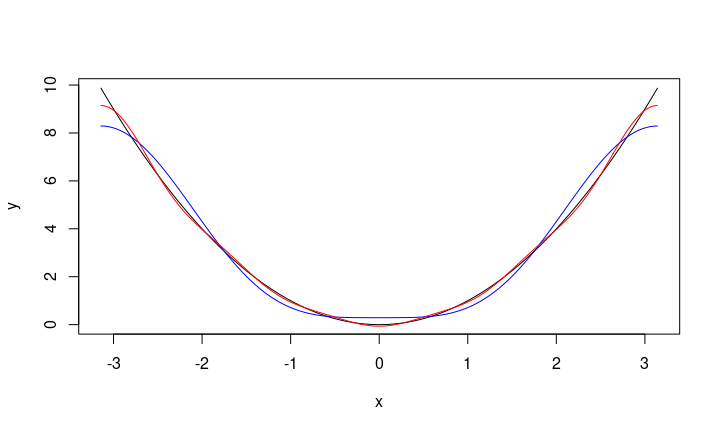

## Ejemplo (continuación)

La expresión del error será en este caso: \[ \begin{align*} E(a_i,b_j)= & \int_{-\pi}^\pi f(x)^2\, dx-\pi\left(\frac{a_0^2}{2}+\sum_{k=1}^n a_k^2+\sum_{k=1}^{n-1}b_k^2\right)=\int_{-\pi}^\pi x^4\, dx-\pi\left(\frac{1}{2}\cdot\left(\frac{2\pi^2}{3}\right)^2+\sum_{k=1}^n\left(\frac{4\cdot (-1)^k}{k^2}\right)^2 \right)\\ = & \left[\frac{x^5}{5}\right]_{-\pi}^\pi -\pi\left(\frac{2\pi^4}{9}+16\sum_{k=1}^n\frac{1}{k^4}\right)=\frac{\pi^5}{5}-\frac{(-\pi)^5}{5}-\frac{2\pi^5}{9}-16\pi\sum_{k=1}^n\frac{1}{k^4}=\frac{2\pi^5}{5}-\frac{2\pi^5}{9}-16\pi\sum_{k=1}^n\frac{1}{k^4}\\ = & \frac{8\pi^5}{45}-16\pi\sum_{k=1}^n\frac{1}{k^4} \end{align*} \]

Si en la expresión anterior hacemos tender \(n\to\infty\) hacia infinito, podemos hallar la suma de la serie \(\displaystyle\sum_{k=1}^\infty\frac{1}{k^4}\): \[ \frac{8\pi^5}{45}-16\pi\sum_{k=1}^\infty\frac{1}{k^4}=0,\ \Rightarrow \sum_{k=1}^\infty\frac{1}{k^4}=\frac{\frac{8\pi^5}{45}}{16\pi}=\frac{\pi^4}{90}. \]

## Ejemplo (continuación)

La tabla siguiente nos da la expresión del error para distintos valores de \(n\):

| \(n\) | Error |
| --- | --- |
| \(2\) | \(0.9964244\) |
| \(3\) | \(0.3758629\) |
| \(4\) | \(0.1795134\) |
| \(5\) | \(0.0990886\) |
| \(6\) | \(0.0603035\) |
| \(7\) | \(0.0393683\) |
| \(8\) | \(0.0270964\) |

## Aproximación trigonométrica discreta

En la sección anterior, vimos cómo aproximar una función \(f\) **integrable** en \([-\pi,\pi]\) por una función trigonométrica \[ S_n(x)=\frac{a_0}{2}+\sum_{j=1}^n a_j\cos(jx)+\sum_{j=1}^{n-1} b_j\sin(jx), \] hallando los coeficientes \(a_j\), \(j=0,1,\ldots,n\) y \(b_j\), \(j=1,\ldots,n-1\) que minimizan la **función error**: \[ \begin{align*} & E(a_0,a_1,\ldots,a_n,b_1,b_2,\ldots,b_{n-1})= \int_{-\pi}^{\pi}(f(x)-S_n(x))^2\, dx\\ &\quad = \int_{-\pi}^{\pi}\left(f(x)-\left(\frac{a_0}{2}+\sum_{j=1}^{n} a_j\cos(jx)+\sum_{j=1}^{n-1}b_j\sin(jx))\right)\right)^2\, dx. \end{align*} \] En esta sección vamos a ver la **versión discreta** de dicha aproximación.

## Aproximación trigonométrica discreta

Concretamente, sea \(m\) un entero positivo. Consideramos los \(2m\) puntos siguientes **equiespaciados** en el intervalo \([-\pi,\pi]\): \[ x_j =-\pi +\frac{j\pi}{m},\ j=0,\ldots,2m-1. \] Supongamos que nos dan \(y_j\), \(j=0,1,\ldots,2m-1\) las \(2m\) **ordenadas** correspondientes a dichos \(2m\) puntos.

Es decir, los puntos en el plano \((x_j,y_j)\), \(j=0,1,\ldots,2m-1\) forman nuestra **nube de puntos**.

## Aproximación trigonométrica discreta

Nos planteamos el problema siguiente:

Problema de minimización trigonométrica discreta.

Queremos hallar una función \(S_n(x)\in T_n\), con \(n<m\), \[ S_n(x)=\frac{a_0}{2}+\sum_{j=1}^n a_j\cos(jx)+\sum_{j=1}^{n-1} b_j\sin(jx), \] que minimice la **función error** siguiente: \[ \begin{align*} & E(a_0,a_1,\ldots,a_n,b_1,b_2,\ldots,b_{n-1})= \sum_{i=0}^{2m-1}(y_i-S_n(x_i))^2\\ &\quad = \sum_{i=0}^{2m-1}\left(y_i-\left(\frac{a_0}{2}+\sum_{j=1}^{n} a_j\cos(jx_i)+\sum_{j=1}^{n-1}b_j\sin(jx_i))\right)\right)^2\,. \end{align*} \]

## Cálculo del mínimo de la función error

Observación.

La condición \(n<m\) se impone ya que si \(n=m\), basta hallar la **función trigonométrica** \(S_n(x)\) que interpole la nube de puntos \((x_k,y_k),\ k=0,1,\ldots,2m-1\), es decir \(S_n(x_k)=y_k,\ k=0,1,\ldots,2m-1\) y la **función error** sería mínima al ser nula: \(E(a_i,b_j)=0\).

En el caso \(n=m\), tenemos \(2m\) ecuaciones \(S_n(x_k)=y_k,\ k=0,1,\ldots,2m-1\) y \(2n=2m\) incógnitas \(a_0,a_1,\ldots,a_n,b_1,\ldots,b_{n-1}\), (\(n+1+n-1=2n\)).

## Cálculo del mínimo de la función error

El Teorema siguiente nos da la función \(S_n(x)\) buscada:

Teorema: función que minimiza la función error.

La función \(S_n(x)\) que minimiza la función error es la siguiente: \[ S_n(x)=\frac{a_0}{2}+\sum_{j=1}^n a_j\cos(jx)+\sum_{j=1}^{n-1} b_j\sin(jx), \] con: \[ \begin{align*} a_k = & \frac{1}{m}\sum_{i=0}^{2m-1}y_i\cos(kx_i),\ k=0,1,\ldots,n,\\ b_k = & \frac{1}{m}\sum_{i=0}^{2m-1}y_i\sin(kx_i),\ k=1,2,\ldots,n-1. \end{align*} \]

## Cálculo del mínimo de la función error

De forma parecida al caso continuo, necesitamos el lema siguiente para la demostración del Teorema:

Lema.

Sean \(k\), \(l\) y \(m\) tres enteros. Entonces se cumplen las igualdades siguientes:

- si \(k\) no es múltiplo de \(2m\), \[ \sum_{j=0}^{2m-1}\cos(kx_j)= 0,\quad \sum_{j=0}^{2m-1}\sin(kx_j)=0. \]
- si \(k\) no es múltiplo de \(m\), \[ \sum_{j=0}^{2m-1}\cos(kx_j)^2 = m,\quad \sum_{j=0}^{2m-1}\sin^2(kx_j)=m. \]

## Cálculo del mínimo de la función error

Lema (continuación).

- si \(k+l\) y \(l-k\) no son múltiplos de \(2m\), \[ \sum_{j=0}^{2m-1}\cos(kx_j)\sin(lx_j) = 0. \]
- si \(k+l\) y \(l-k\) no son múltiplos de \(2m\) y \(k\neq l\), \[ \sum_{j=0}^{2m-1}\cos(kx_j)\cos(lx_j) = 0,\quad \sum_{j=0}^{2m-1}\sin(kx_j)\sin(lx_j) = 0. \]

## Demostración del lema

Veamos la primera parte del lema.

Supongamos que \(k\) no es múltiplo de \(2m\).

Recordemos la **fórmula de Euler** que dice: \(\mathrm{e}^{\mathrm{i}t}=\cos(t)+\mathrm{i}\sin(t)\), donde \(t\) es un número real cualquiera.

Entonces, podemos escribir: \[ \begin{align*} & \sum_{j=0}^{2m-1}\cos(kx_j)+\mathrm{i}\sum_{j=0}^{2m-1}\sin(kx_j)=\sum_{j=0}^{2m-1}(\cos(kx_j)+\mathrm{i}\sin(k x_j))=\sum_{j=0}^{2m-1}\mathrm{e}^{\mathrm{i}kx_j}=\sum_{j=0}^{2m-1}\mathrm{e}^{\mathrm{i}k\left(-\pi +\frac{j\pi}{m}\right)}=\mathrm{e}^{-\mathrm{i}k\pi}\sum_{j=0}^{2m-1}\mathrm{e}^{\frac{\mathrm{i}kj\pi}{m}}. \end{align*} \] La suma \(\displaystyle\mathrm{e}^{\frac{\mathrm{i}kj\pi}{m}}\) es la suma de una serie **geométrica** de **razón** \(r=\mathrm{e}^{\frac{\mathrm{i}k\pi}{m}}\). Como \(r\neq 1\) ya que \(k\) no es múlpiplo de \(2m\), podemos usar la fórmula \(\displaystyle\sum_{j=0}^{2m-1}r^j =\frac{1-r^{2m}}{1-r}\): \[ \sum_{j=0}^{2m-1}\cos(kx_j)+\mathrm{i}\sum_{j=0}^{2m-1}\sin(kx_j)=\mathrm{e}^{-\mathrm{i}k\pi}\cdot\frac{1-\left(\mathrm{e}^{\frac{\mathrm{i}k\pi}{m}}\right)^{2m}}{1-\mathrm{e}^{\frac{\mathrm{i}k\pi}{m}}}=\mathrm{e}^{-\mathrm{i}k\pi}\cdot\frac{1-\mathrm{e}^{2\mathrm{i}k\pi}}{1-\mathrm{e}^{\frac{\mathrm{i}k\pi}{m}}}=0, \] ya que, en general \(\mathrm{e}^{2\mathrm{i}k\pi}=1\) si \(k\) es un entero.

Quedan probadas las expresiones de la primera parte del lema: \(\displaystyle \sum_{j=0}^{2m-1}\cos(kx_j)=0,\ \sum_{j=0}^{2m-1}\sin(kx_j)=0\).

## Demostración del lema (continuación)

Veamos la segunda parte del lema, es decir, que si \(k\) no es múltiplo de \(m\), \(\displaystyle\sum_{j=0}^{2m-1}\cos(kx_j)^2 = m,\ \sum_{j=0}^{2m-1}\sin^2(kx_j)=m\): \[ \begin{align*} \sum_{j=0}^{2m-1}\cos(kx_j)^2 = & \sum_{j=0}^{2m-1} \frac{1}{2}(1+\cos(2kx_j))=\frac{1}{2}\left(\sum_{j=0}^{2m-1} 1+\sum_{j=0}^{2m-1}\cos(2kx_j)\right)=\frac{1}{2}\cdot 2m=m, \end{align*} \] ya que si \(k\) no es múltiplo de \(m\), \(2k\) no es múltiplo de \(2m\) y, por tanto, \(\displaystyle\sum_{j=0}^{2m-1}\cos(2kx_j)=0\), aplicando la expresión de la primera parte del lema.

De la misma manera, \[ \begin{align*} \sum_{j=0}^{2m-1}\sin(kx_j)^2 = & \sum_{j=0}^{2m-1} \frac{1}{2}(1-\cos(2kx_j))=\frac{1}{2}\left(\sum_{j=0}^{2m-1} 1-\sum_{j=0}^{2m-1}\cos(2kx_j)\right)=\frac{1}{2}\cdot 2m=m, \end{align*} \] usando un razonamiento similar.

## Demostración del lema (continuación)

Demostremos la tercera parte del lema: sean \(k\) y \(l\) tal que \(k+l\) y \(l-k\) no son múltiplos de \(2m\). Entonces: \[ \begin{align*} \sum_{j=0}^{2m-1}\cos(kx_j)\sin(lx_j) = & \frac{1}{2}\sum_{j=0}^{2m-1}(\sin((l+k)x_j)+\sin((l-k)x_j))=\frac{1}{2}(0+0)=0, \end{align*} \] usando la primera parte del lema usando que \(k+l\) y \(l-k\) no son múltiplos de \(2m\).

La demostración de la cuarta parte del lema es la siguiente: \[ \begin{align*} \sum_{j=0}^{2m-1}\cos(kx_j)\cos(lx_j) = & \frac{1}{2}\sum_{j=0}^{2m-1}(\cos((k-l)x_j)+\cos((k+l)x_j))=\frac{1}{2}(0+0)=0,\\ \sum_{j=0}^{2m-1}\sin(kx_j)\sin(lx_j) = & \frac{1}{2}\sum_{j=0}^{2m-1}(\cos((k-l)x_j)-\cos((k+l)x_j))=\frac{1}{2}(0+0)=0 \end{align*} \] usando la primera parte del lema usando que \(k+l\) y \(l-k\) no son múltiplos de \(2m\) y \(k\neq l\).

## Demostración del Teorema

Para hallar el **mínimo** de la función error, dichos coeficientes tienen que verificar el siguiente **sistema de ecuaciones**: \[ \begin{align*} \frac{\partial E}{\partial a_k}(a_0,\ldots,a_n,b_1,\ldots,b_{n-1})= & 0,\ k=0,1,\ldots,n,\\ \frac{\partial E}{\partial b_k}(a_0,\ldots,a_n,b_1,\ldots,b_{n-1})= & 0,\ k=1,\ldots,n-1. \end{align*} \] A continuación vamos a simplificar el sistema de ecuaciones anterior. Empecemos por el coeficiente \(a_0\): \[ \begin{align*} \frac{\partial E}{\partial a_0}= &-2\sum_{i=0}^{2m-1}\left(y_i-\left(\frac{a_0}{2}+ \sum_{j=1}^{n}a_j\cos(jx_i)+\sum_{j=1}^{n-1}b_j\sin(j x_i)\right)\right)\frac{1}{2} \\ = & -\left(\sum_{i=0}^{2m-1} y_i-a_0\cdot m-\sum_{j=1}^{n} a_j\sum_{i=0}^{2m-1}\cos(jx_i)-\sum_{j=1}^{n-1} b_j\sum_{i=0}^{2m-1}\sin(jx_i)\right)=- \left(\sum_{i=0}^{2m-1} y_i-a_0\cdot m\right)=0, \end{align*} \] ya que como \(n<m\), \(j=1,\ldots,n\) no es múltiplo de \(2m\) y por tanto, \(\displaystyle\sum_{i=0}^{2m-1}\cos(jx_i)=\sum_{i=0}^{2m-1}\sin(jx_i)=0\), usando el lema anterior.

El coeficiente \(a_0\) será, pues, \[ \sum_{i=0}^{2m-1} y_i-a_0\cdot m=0,\ \Rightarrow a_0=\frac{1}{m}\sum_{i=0}^{2m-1} y_i. \]

## Demostración del Teorema (continuación)

La ecuación correspondiente al coeficiente \(a_k\) será: \[ \begin{align*} \frac{\partial E}{\partial a_k}= &-2\sum_{i=0}^{2m-1}\left(\left(y_i-\left(\frac{a_0}{2}+ \sum_{j=1}^{n}a_j\cos(jx_i)+\sum_{j=1}^{n-1}b_j\sin(jx_i)\right)\right)\cos(kx_i)\right) \\ = & -2\left(\sum_{i=0}^{2m-1} y_i\cos(kx_i)-\frac{a_0}{2}\sum_{i=0}^{2m-1}\cos(kx_i)-\sum_{j=1}^{n} a_j\sum_{i=0}^{2m-1}\cos(jx_i)\cos(kx_i)-\sum_{j=1}^{n-1} b_j\sum_{i=0}^{2m-1}\sin(jx_i)\cos(kx_i)\right)\\ = & -2\left(\sum_{i=0}^{2m-1} y_i\cos(kx_i)-a_k\sum_{i=0}^{2m-1}\cos^2(kx_i)\right)=-2\left(\sum_{i=0}^{2m-1} y_i\cos(kx_i)-m\cdot a_k\right), \end{align*} \] donde en la penúltima igualdad hemos usado la primera, tercera y cuarta parte del lema y en la última igualdad, la segunda parte del lema. Hay que tener en cuenta que \(j+k\leq 2n<2m\), \(j-k\leq 2n<2m\) y por tanto no son múltiplos de \(2m\).

El coeficiente \(a_k\) será, pues, \[ \sum_{i=0}^{2m-1} y_i\cos(kx_i)-m\cdot a_k=0,\ \Rightarrow a_k=\frac{1}{m}\sum_{i=0}^{2m-1} y_i\cos(kx_i). \]

## Demostración del Teorema (continuación)

La ecuación correspondiente al coeficiente \(b_k\) será: \[ \begin{align*} \frac{\partial E}{\partial b_k}= &-2\sum_{i=0}^{2m-1}\left(\left(y_i-\left(\frac{a_0}{2}+ \sum_{j=1}^{n}a_j\cos(jx_i)+\sum_{j=1}^{n-1}b_j\sin(jx_i)\right)\right)\sin(kx_i)\right) \\ = & -2\left(\sum_{i=0}^{2m-1} y_i\sin(kx_i)-\frac{a_0}{2}\sum_{i=0}^{2m-1}\sin(kx_i)-\sum_{j=1}^{n} a_j\sum_{i=0}^{2m-1}\cos(jx_i)\sin(kx_i)-\sum_{j=1}^{n-1} b_j\sum_{i=0}^{2m-1}\sin(jx_i)\sin(kx_i)\right)\\ = & -2\left(\sum_{i=0}^{2m-1} y_i\sin(kx_i)-b_k\sum_{i=0}^{2m-1}\sin^2(kx_i)\right)=-2\left(\sum_{i=0}^{2m-1} y_i\sin(kx_i)-m\cdot b_k\right), \end{align*} \] donde también en la penúltima igualdad hemos usado la primera, tercera y cuarta parte del lema y en la última igualdad, la segunda parte del lema. Hay que tener en cuenta que \(j+k\leq 2n<2m\), \(j-k\leq 2n<2m\) y por tanto no son múltiplos de \(2m\).

El coeficiente \(b_k\) será, pues, \[ \sum_{i=0}^{2m-1} y_i\sin(kx_i)-m\cdot b_k=0,\ \Rightarrow b_k=\frac{1}{m}\sum_{i=0}^{2m-1} y_i\sin(kx_i). \]

## Aprox. trigonométrica discreta. Pseudocódigo

### Caso 1: Supondremos que el **lenguaje de programación** en el que se va a programar el código empieza a inicializar en \(1\):

- `INPUT número de puntos de la nube` \(m\), `puntos de la nube` \((x_k,y_k)\), \(k=1,\ldots,2\cdot m\), `valor` \(n\).
- `Set` \(\mathbf{a}=\mathbf{0}\). (`Inicializamos los vectores` \(\mathbf{a}\) `y` \(\mathbf{b}\) `donde guardaremos` \(a_k\), \(k=1,\ldots,n+1\) `y` \(b_k,\ k=1,\ldots,n-1\).)
- `Set` \(\mathbf{b}=\mathbf{0}\).
- `For i=1,...,2*m` (`primero calculamos` \(a_1\))
  - `Set` \(a_1=a_1+y_i\)
- `Set` \(a_1=\frac{a_1}{m}\)

## Aprox. trigonométrica discreta. Pseudocódigo

- `For k=2,...,n` (`Calculamos` \(a_{k}\), `las componentes del vector` \(\mathbf{a}\) `y las componentes del vector` \(\mathbf{b}\), `para` \(k=2,\ldots,n\))
  - `For i=1,...,2*m`
    - `Set` \(a_k=a_k+y_i\cdot\cos((k-1)\cdot x_i)\)
    - `Set` \(b_{k-1}=b_{k-1}+y_i\cdot\sin((k-1)\cdot x_i)\)
  - `Set` \(a_k =\frac{a_k}{m}\)
  - `Set` \(b_k =\frac{b_k}{m}\)
- `For i=1,...,2*m` (`Calculamos` \(a_{n+1}\))
  - `Set` \(a_{n+1}=a_{n+1}+y_i\cdot\cos(n\cdot x_i)\)
- `Set` \(a_{n+1}=\frac{a_{n+1}}{m}\).
- `Print` \(a_1,a_2,\ldots,a_{n+1},b_1,\ldots,b_{n-1}\).

## Aprox. trigonométrica discreta. Pseudocódigo

### Caso 2: Supondremos que el **lenguaje de programación** en el que se va a programar el código empieza a inicializar en \(0\) como `Python`:

- `INPUT número de puntos de la nube` \(m\), `puntos de la nube` \((x_k,y_k)\), \(k=0,\ldots,2\cdot m-1\), `valor` \(n\).
- `Set` \(\mathbf{a}=\mathbf{0}\). (`Inicializamos los vectores` \(\mathbf{a}\) `y` \(\mathbf{b}\) `donde guardaremos` \(a_k\), \(k=0,\ldots,n\) `y` \(b_k,\ k=1,\ldots,n-1\).)
- `Set` \(\mathbf{b}=\mathbf{0}\).
- `For i=0,...,2*m-1` (`primero calculamos` \(a_0\))
  - `Set` \(a_0=a_0+y_i\)
- `Set` \(a_0=\frac{a_0}{m}\)

## Aprox. trigonométrica discreta. Pseudocódigo

- `For k=1,...,n-1` (`Calculamos` \(a_{k}\), `las componentes del vector` \(\mathbf{a}\) `y las componentes del vector` \(\mathbf{b}\), `para` \(k=1,\ldots,n-1\))
  - `For i=0,...,2*m-1`
    - `Set` \(a_k=a_k+y_i\cdot\cos(k\cdot x_i)\)
    - `Set` \(b_k=b_k+y_i\cdot\sin(k\cdot x_i)\)
  - `Set` \(a_k =\frac{a_k}{m}\)
  - `Set` \(b_k =\frac{b_k}{m}\)
- `For i=0,...,2*m-1` (`Calculamos` \(a_{n}\))
  - `Set` \(a_{n}=a_{n}+y_i\cdot\cos(n\cdot x_i)\)
- `Set` \(a_{n}=\frac{a_{n}}{m}\).
- `Print` \(a_0,a_1,\ldots,a_{n},b_1,\ldots,b_{n-1}\).

## Ejemplo

Vamos a hallar la aproximación discreta con \(n=2\), de la nube de puntos \((x_k,y_k)\), \(k=0,1,\ldots,2m-1\), con \(m=5\), considerando \(y_k =f(x_k)=x_k^2\), escogiendo la misma función que en el caso continuo.

Los valores \(x_k\) serán: \[ \begin{align*} x_k = & -\pi+\frac{2k\pi}{10},\ k=0,1,\ldots,9,\\ x_k = & -3.141593, -2.513274, -1.884956, -1.256637, -0.628319, 0, 0.628319, 1.256637, 1.884956, 2.513274. \end{align*} \] Los valores \(y_k\) serán: \[ \begin{align*} y_k = & x_k^2,\ k=0,1,\ldots,9,\\ y_k = & 9.869604, 6.316547, 3.553058, 1.579137, 0.394784, 0, 0.394784, 1.579137, 3.553058, 6.316547. \end{align*} \] El valor \(a_0\) será: \[ \begin{align*} a_0= & \frac{1}{m}\sum_{i=0}^{9}y_i=\frac{1}{5}(9.8696044+6.3165468+3.5530576+1.5791367+0.3947842+0+0.3947842\\ & \quad +1.5791367+3.5530576+6.3165468)=6.711331. \end{align*} \]

## Ejemplo (continuación)

Los valores \(a_1\) y \(a_2\) serán: \[ \begin{align*} a_1 = &\frac{1}{m}\sum_{i=0}^{9}y_i\cos(x_i)=\frac{1}{5}(9.8696044\cdot\cos(-3.1415927)+6.3165468\cdot\cos(-2.5132741)\\ & \quad +3.5530576\cdot\cos(-1.8849556)+1.5791367\cdot\cos(-1.2566371)+0.3947842\cdot\cos(-0.6283185)\\ & \quad +0\cdot\cos(0)+0.3947842\cdot\cos(0.6283185) +1.5791367\cdot\cos(1.2566371)\\ & \quad +3.5530576\cdot\cos(1.8849556)+6.3165468\cdot\cos(2.5132741))=-4.1342336,\\ a_2 = &\frac{1}{m}\sum_{i=0}^{9}y_i\cos(2x_i)=\frac{1}{5}(9.8696044\cdot\cos(2\cdot (-3.1415927))+6.3165468\cdot\cos(2\cdot (-2.5132741))\\ & \quad +3.5530576\cdot\cos(2\cdot (-1.8849556))+1.5791367\cdot\cos(2\cdot (-1.2566371))\\ & \quad +0.3947842\cdot\cos(2\cdot (-0.6283185)) +0\cdot\cos(2\cdot0)+0.3947842\cdot\cos(2\cdot0.6283185)\\ & \quad +1.5791367\cdot\cos(2\cdot1.2566371) +3.5530576\cdot\cos(2\cdot1.8849556)+6.3165468\cdot\cos(2\cdot2.5132741))\\ = & 1.1426741. \end{align*} \] El valor \(b_1\) vale: \[ \begin{align*} b_1 = &\frac{1}{m}\sum_{i=0}^{9}y_i\sin(x_i)=\frac{1}{5}(9.8696044\cdot\sin(-3.1415927)+6.3165468\cdot\sin(-2.5132741)\\ & \quad +3.5530576\cdot\sin(-1.8849556)+1.5791367\cdot\sin(-1.2566371)+0.3947842\cdot\sin(-0.6283185)\\ & \quad +0\cdot\sin(0)+0.3947842\cdot\sin(0.6283185) +1.5791367\cdot\sin(1.2566371)\\ & \quad +3.5530576\cdot\sin(1.8849556)+6.3165468\cdot\sin(2.5132741))=0,\\ \end{align*} \]

## Ejemplo (continuación)

La función \(S_{2}(x)\) será: \[ \begin{align*} S_{2}(x) = & \frac{6.711331}{2}-4.1342336\cdot\cos(x)+1.1426741\cdot\cos(2x)\\ = &3.3556655-4.1342336\cdot\cos(x)+1.1426741\cdot\cos(2x). \end{align*} \] La gráfica siguiente muestra la nube de puntos (en negro) y la aproximación \(S_{2}(x)\) en rojo.

## Ejemplo (continuación)

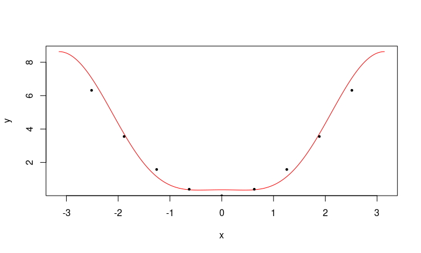

## Ejemplo (continuación)

El error cometido será: \[ \begin{align*} & E(a_0,a_1,a_2,b_1)= (9.8696044-(3.3556655-4.1342336\cdot\cos(-3.1415927)+1.1426741\cdot\cos(2\cdot (-3.1415927))))^2\\ &\quad +(6.3165468-(3.3556655-4.1342336\cdot\cos(-2.5132741)+1.1426741\cdot\cos(2\cdot (-2.5132741))))^2 \\ &\quad +(3.5530576-(3.3556655-4.1342336\cdot\cos(-1.8849556)+1.1426741\cdot\cos(2\cdot (-1.8849556))))^2\\ &\quad +(1.5791367-(3.3556655-4.1342336\cdot\cos(-1.2566371)+1.1426741\cdot\cos(2\cdot (-1.2566371))))^2\\ &\quad +(0.3947842-(3.3556655-4.1342336\cdot\cos(-0.6283185)+1.1426741\cdot\cos(2\cdot (-0.6283185))))^2\\ &\quad +(0-(3.3556655-4.1342336\cdot\cos(0)+1.1426741\cdot\cos(2\cdot 0)))^2\\ &\quad +(0.3947842-(3.3556655-4.1342336\cdot\cos(0.6283185)+1.1426741\cdot\cos(2\cdot 0.6283185)))^2\\ &\quad +(1.5791367-(3.3556655-4.1342336\cdot\cos(1.2566371)+1.1426741\cdot\cos(2\cdot 1.2566371)))^2\\ &\quad +(3.5530576-(3.3556655-4.1342336\cdot\cos(1.8849556)+1.1426741\cdot\cos(2\cdot 1.8849556)))^2\\ &\quad +(6.3165468-(3.3556655-4.1342336\cdot\cos(2.5132741)+1.1426741\cdot\cos(2\cdot 2.5132741)))^2 = 3.1612443. \end{align*} \]

## Transformada rápida de Fourier

## Introducción

Cuando en la **aproximación trigonométrica discreta**, el valor de \(m\) y \(n\) coinciden, \(n=m\), el valor de la aproximación \(S_n(x)\) se denomina **serie de Fourier discreta** correspondiente a la **nube de puntos** \((x_k,y_k),\ k=0,\ldots,2m-1\): \[ S_n(x)=\frac{a_0}{2}+\sum_{j=1}^n a_j\cos(jx)+\sum_{j=1}^{n-1} b_j\sin(jx). \] En este caso, la función \(S_n(x)\) interpola a los puntos \((x_k,y_k)\), \(k=0,1,\ldots,2m-1\) ya que tenemos \(n+1+n-1=2n\) coeficientes \(a_k,\ k=0,\ldots,n\) y \(b_k,\ k=1,\ldots,n-1\) y \(2m=2n\) condiciones: \[ S_n(x_k)=y_k,\ k=0,1,\ldots,2m-1=2n-1. \]

## Introducción

Ahora bien, las expresiones de las \(a_k\), \(k=0,1,\ldots,n\), \(b_k\), \(k=1,\ldots,n-1\) son las que hemos deducido anteriormente: \[ \begin{align*} a_k = & \frac{1}{m}\sum_{i=0}^{2m-1}y_i\cos(kx_i),\ k=0,1,\ldots,n-1,\\ b_k = & \frac{1}{m}\sum_{i=0}^{2m-1}y_i\sin(kx_i),\ k=0,1,\ldots,n-1, \end{align*} \] excepto la expresión para \(a_n\).

## Introducción

Para deducir la expresión para \(a_n\), hacíamos lo siguiente: \[ \begin{align*} \frac{\partial E}{\partial a_n}= &-2\sum_{i=0}^{2m-1}\left(\left(y_i-\left(\frac{a_0}{2}+ \sum_{j=1}^{n}a_j\cos(jx_i)+\sum_{j=1}^{n-1}b_j\sin(jx_i)\right)\right)\cos(nx_i)\right) \\ = & -2\left(\sum_{i=0}^{2m-1} y_i\cos(nx_i)-\frac{a_0}{2}\sum_{i=0}^{2m-1}\cos(nx_i)-\sum_{j=1}^{n} a_j\sum_{i=0}^{2m-1}\cos(jx_i)\cos(nx_i)-\sum_{j=1}^{n-1} b_j\sum_{i=0}^{2m-1}\sin(jx_i)\cos(nx_i)\right)\\ = & -2\left(\sum_{i=0}^{2m-1} y_i\cos(nx_i)-a_n\sum_{i=0}^{2m-1}\cos^2(nx_i)\right). \end{align*} \] Nos falta calcular \(\displaystyle\sum_{i=0}^{2m-1}\cos^2(nx_i)=\sum_{i=0}^{2m-1}\cos^2(mx_i)\) pero no podemos aplicar el lema ya que recordemos que el lema nos da la suma \(\displaystyle\sum_{i=0}^{2m-1}\cos^2(k x_i)=m\), **si \(k\) no es múltiplo de \(m\)** pero en nuestro caso \(k=n\) y como \(n=m\), \(k=m\) es múltiplo de \(m\).

## Introducción

El lema siguiente nos calcula la suma solicitada:

Lema. \[ \sum_{i=0}^{2m-1}\cos^2(mx_i) =2m. \]

**Demostración**

\[ \begin{align*} \sum_{i=0}^{2m-1}\cos^2(mx_i) = &\sum_{i=0}^{2m-1}\frac{1}{2}(1+\cos(2mx_i))=\frac{1}{2}\left(\sum_{i=0}^{2m-1} 1+\sum_{i=0}^{2m-1} \cos(2mx_i)\right)=\frac{1}{2}\left(2m+\sum_{i=0}^{2m-1} \cos(2mx_i)\right) \\ = & \frac{1}{2}\left(2m+\sum_{i=0}^{2m-1} \cos\left((2m \left(-\pi +\frac{i\pi}{m}\right)\right)\right) =\frac{1}{2}\left(2m+\sum_{i=0}^{2m-1} \cos\left((-2m\pi +2i\pi\right)\right)\\ = &\frac{1}{2}\left(2m+\sum_{i=0}^{2m-1} \cos\left((-2m+2i)\pi\right)\right)=\frac{1}{2}\left(2m+\sum_{i=0}^{2m-1} 1\right)=\frac{1}{2}\left(2m+2m\right)=2m. \end{align*} \]

## Introducción

Entonces: \[ \begin{align*} \frac{\partial E}{\partial a_n}= & -2\left(\sum_{i=0}^{2m-1} y_i\cos(nx_i)-a_n\sum_{i=0}^{2m-1}\cos^2(nx_i)\right)=0,\ \Rightarrow \\ \sum_{i=0}^{2m-1} y_i\cos(nx_i)-2ma_n= & 0. \end{align*} \] El valor de \(a_n\) será, pues, · \[ a_n=\frac{1}{2m}\sum_{i=0}^{2m-1}y_i\cos(n x_i). \]

## Serie de Fourier discreta

La **función trigonométrica interpoladora** o la expresión de la **serie de Fourier discreta** correspondiente a la nube de puntos \((x_k,y_k)\), \(k=0,1,\ldots,2m-1\) será: \[ S_m(x)=\frac{a_0}{2}+\sum_{j=1}^m a_j\cos(jx)+\sum_{j=1}^{m-1}b_j\sin(jx), \] con \[ \begin{align*} a_k = & \frac{1}{m}\sum_{i=0}^{2m-1}y_i\cos(kx_i),\ k=0,1,\ldots,m-1,\ a_m = \frac{1}{2m}\sum_{i=0}^{2m-1}y_i\cos(m x_i),\\ b_k = & \frac{1}{m}\sum_{i=0}^{2m-1}y_i\sin(kx_i),\ k=0,1,\ldots,m-1,\\ \end{align*} \] donde sólo hemos escrito el valor \(m\) ya que suponemos que \(n=m\).

## Serie de Fourier discreta

De cara a tener una expresión más **compacta** en la expresión de los coeficientes \(a_k\), redefinimos \(a_m\) como \(\displaystyle a_m=\frac{1}{m}\sum_{i=0}^{2m-1}y_i\cos(m x_i)\) y escribimos la **serie de Fourier discreta** como: \[ S_m(x)=\frac{a_0+a_m\cos(mx)}{2}+\sum_{j=1}^{m-1} a_j\cos(jx)+\sum_{j=1}^{m-1}b_j\sin(jx), \] con \[ \begin{align*} a_k = & \frac{1}{m}\sum_{i=0}^{2m-1}y_i\cos(kx_i),\ k=0,1,\ldots,m,\\ b_k = & \frac{1}{m}\sum_{i=0}^{2m-1}y_i\sin(kx_i),\ k=0,1,\ldots,m-1.\\ \end{align*} \]

## Transformada rápida de Fourier

Calcular los valores \(a_k\), \(k=0,\ldots,m-1\) y \(b_k\), \(k=1,\ldots,m-1\) requiere en total: \((2m)^2=4m^2\) multiplicaciones/divisiones y \((2m)^2=4m^2\) sumas/restas ya que:

|  | Cálculo de \(a_k\) | Cálculo de \(b_k\) |
| --- | --- | --- |
| Sumas/restas | \(2m\) | \(2m\) |
| Multiplicaciones/divisiones | \(2m\) | \(2m\) |
| Total (hay \(m+1\) coeficientes \(a_k\) y \(m-1\) coeficientes \(b_k\), en total \(m+1+m-1=2m\) coeficientes) | \((2m)\cdot (2m)=4m^2\) | \((2m)\cdot (2m)=4m^2\) |

## Transformada rápida de Fourier

El **número total de operaciones** es de orden \(m^2\): \(O(m^2)\).

Vamos a diseñar un algoritmo que reduce el **número de operaciones** a \(O(m\ln_2(m))\). Dicho algoritmo se denomina **transformada rápida de Fourier**.

En primer lugar, consideramos la función siguiente: \[ \frac{1}{m}\sum_{k=0}^{2m-1}c_k \mathrm{e}^{\mathrm{i}kx},\mbox{ con }c_k=\sum_{j=0}^{2m-1}y_j\mathrm{e}^{\frac{\mathrm{i}k\pi j}{m}},\ k=0,1,\ldots,2m-1. \]

## Transformada rápida de Fourier

Veamos a continuación que los coeficientes \(a_k\) y \(b_k\) se pueden calcular a partir de los coeficientes \(c_k\):

Proposición.

La relación entre los coeficientes \(c_k\), \(a_k\) y \(b_k\) es la siguiente: \[ a_k+\mathrm{i}b_k=\frac{(-1)^k}{m}c_k,\ k=0,1,\ldots,m, \] donde suponemos que \(b_0=b_m=0\).

Por tanto, si \(k=0\), la relación anterior nos dice que \(a_0 =\frac{(-1)^0}{m}c_0=\frac{c_0}{m}\) y si \(k=m\), \(a_m=\frac{(-1)^m}{m}c_m\).

## Demostración de la proposición

Sea \(k\) un valor entre \(0\) y \(m\). Entonces, \[ \begin{align*} \frac{(-1)^k}{m}c_k = & \frac{1}{m}c_k\cdot\mathrm{e}^{-\mathrm{i}\pi k}=\frac{1}{m}\sum_{j=0}^{2m-1}y_j\mathrm{e}^{\frac{\mathrm{i}k\pi j}{m}}\cdot\mathrm{e}^{-\mathrm{i}\pi k}=\frac{1}{m}\sum_{j=0}^{2m-1}y_j\mathrm{e}^{\mathrm{i}k\left(-\pi+\frac{\pi j}{m}\right)}\\ = & \frac{1}{m}\sum_{j=0}^{2m-1}y_j\left(\cos\left(k\left(-\pi+\frac{\pi j}{m}\right)\right)+\mathrm{i}\sin\left(k\left(-\pi+\frac{\pi j}{m}\right)\right)\right)=\frac{1}{m}\sum_{j=0}^{2m-1}y_j\left(\cos\left(kx_j\right)+\mathrm{i}\sin\left(k x_j\right)\right)\\ = & \frac{1}{m}\sum_{j=0}^{2m-1}y_j\cos\left(kx_j\right)+\mathrm{i}\frac{1}{m}\sum_{j=0}^{2m-1}y_j\sin\left(kx_j\right)=a_k+\mathrm{i}b_k, \end{align*} \] tal como queríamos demostrar.

## Transformada rápida de Fourier

A partir de ahora, supongamos que \(m\) es un **potencia de \(2\)**, es decir, que existe un entero \(p\) tal que \(m=2^p\).

Para empezar, calculemos para \(k=0,1,\ldots,m-1\), la suma siguiente: \[ c_k+c_{m+k}=\sum_{j=0}^{2m-1}y_j\mathrm{e}^{\frac{\mathrm{i}k\pi j}{m}}+\sum_{j=0}^{2m-1}y_j\mathrm{e}^{\frac{\mathrm{i}(m+k)\pi j}{m}}=\sum_{j=0}^{2m-1}y_j\mathrm{e}^{\frac{\mathrm{i}k\pi j}{m}}\left(1+\mathrm{e}^{\mathrm{i}\pi j}\right). \] El valor de \(1+\mathrm{e}^{\mathrm{i}\pi j}\) vale: \[ 1+\mathrm{e}^{\mathrm{i}\pi j} =\begin{cases}2,& \mbox{ si } j \mbox{ es par}\\ 0, & \mbox{ si } j\mbox{ es impar.}\end{cases} \]

## Transformada rápida de Fourier

Entonces en la suma \(\displaystyle \sum_{j=0}^{2m-1}y_j\mathrm{e}^{\frac{\mathrm{i}k\pi j}{m}}\left(1+\mathrm{e}^{\mathrm{i}\pi j}\right)\) que aparece en la expresión de \(c_k+c_{m+k}\) sólo se suman los términos en los que \(j\) es **par**, es decir: \[ c_k + c_{m+k}=2\sum_{l=0}^{m-1}y_{2l}\mathrm{e}^{\frac{\mathrm{i}\pi k(2l)}{m}}=2\sum_{l=0}^{m-1}y_{2l}\mathrm{e}^{\frac{\mathrm{i}\pi kl}{\frac{m}{2}}}, \] donde hemos hecho el cambio de índice \(j=2l\) y como \(j=0,1,\ldots,2m-1\), \(l=0,1,\ldots,m-1\).

## Transformada rápida de Fourier

A continuación, calculamos la suma siguiente: \[ c_k-c_{m+k}=\sum_{j=0}^{2m-1}y_j\mathrm{e}^{\frac{\mathrm{i}k\pi j}{m}}-\sum_{j=0}^{2m-1}y_j\mathrm{e}^{\frac{\mathrm{i}(m+k)\pi j}{m}}=\sum_{j=0}^{2m-1}y_j\mathrm{e}^{\frac{\mathrm{i}k\pi j}{m}}\left(1-\mathrm{e}^{\mathrm{i}\pi j}\right). \] El valor de \(1-\mathrm{e}^{\mathrm{i}\pi j}\) vale: \[ 1-\mathrm{e}^{\mathrm{i}\pi j} =\begin{cases}0,& \mbox{ si } j \mbox{ es par}\\ 2, & \mbox{ si } j\mbox{ es impar.}\end{cases} \]

## Transformada rápida de Fourier

Entonces en la suma \(\displaystyle \sum_{j=0}^{2m-1}y_j\mathrm{e}^{\frac{\mathrm{i}k\pi j}{m}}\left(1-\mathrm{e}^{\mathrm{i}\pi j}\right)\) que aparece en la expresión de \(c_k-c_{m+k}\) sólo se suman los términos en los que \(j\) es **impar**, es decir: \[ c_k - c_{m+k}=2\sum_{l=0}^{m-1}y_{2l+1}\mathrm{e}^{\frac{\mathrm{i}\pi k(2l+1)}{m}}=2\mathrm{e}^{\frac{\mathrm{i}k\pi}{m}}\sum_{l=0}^{m-1}y_{2l+1}\mathrm{e}^{\frac{\mathrm{i}\pi kl}{\frac{m}{2}}}, \] donde hemos hecho el cambio de índice \(j=2l+1\) y como \(j=0,1,\ldots,2m-1\), \(l=0,1,\ldots,m-1\).

## Transformada rápida de Fourier

En resumen, hemos deducido lo siguiente: \[ \begin{align*} c_k +c_{m+k}=& 2\sum_{l=0}^{m-1}y_{2l}\mathrm{e}^{\frac{\mathrm{i}\pi kl}{\frac{m}{2}}},\\ c_k -c_{m+k}= & 2\mathrm{e}^{\frac{\mathrm{i}k\pi}{m}}\sum_{l=0}^{m-1}y_{2l+1}\mathrm{e}^{\frac{\mathrm{i}\pi kl}{\frac{m}{2}}}. \end{align*} \]

Ahora viene la **idea clave**: las sumas \(\displaystyle\sum_{l=0}^{m-1}y_{2l}\mathrm{e}^{\frac{\mathrm{i}\pi kl}{\frac{m}{2}}}\) y \(\displaystyle\sum_{l=0}^{m-1}y_{2l+1}\mathrm{e}^{\frac{\mathrm{i}\pi kl}{\frac{m}{2}}}\) corresponden a la definición de los **coeficientes \(c_k\)** para las muestras \(y_0,y_2,\ldots,y_{2m-2}\) (términos pares) y \(y_1,y_3,\ldots,y_{2m-1}\) (términos impares), respectivamente.

Es decir, si sustituimos \(m\) por \(\frac{m}{2}\) en la definición de los \(c_k\) obtenemos los nuevos \(c_k\) que aparecen en los **términos de la derecha en las expresiones de \(c_k+c_{m+k}\) y \(c_{k}-c_{m+k}\)**.

## Transformada rápida de Fourier

Introduzcamos un poco de notación:

- llamamos \(c_k^{(2m)}\) a los **coeficientes \(c_k\)** para la muestra \(y_0,y_1,\ldots,y_{2m-1}\), y
- llamamos \(c_{k,p}^{(m)}\) y \(c_{k,i}^{(m)}\) a los **coeficientes \(c_k\)** para las muestras \(y_0,y_2,\ldots,y_{2m-2}\) (términos **pares**) y \(y_1,y_3,\ldots,y_{2m-1}\) (términos **impares**) respectivamente.

La relación anterior sería: \[ \begin{align*} c_k^{(2m)} +c_{m+k}^{(2m)}=& 2c_{k,p}^{(m)},\\ c_k^{(2m)} -c_{m+k}^{(2m)}= & 2\mathrm{e}^{\frac{\mathrm{i}k\pi}{m}}c_{k,i}^{(m)}, \end{align*} \] para \(k=0,\ldots,m-1\).

## Transformada rápida de Fourier. Algoritmo

La solución del sistema anterior, es decir, el valor de \(c_k^{(2m)}\) y \(c_{m+k}^{(2m)}\) en función de \(c_{k,p}^{(m)}\) y \(c_{k,i}^{(m)}\) es la siguiente: \[ c_k^{(2m)}=c_{k,p}^{(m)}+\mathrm{e}^{\frac{\mathrm{i}k\pi}{m}}c_{k,i}^{(m)},\quad c_{m+k}^{(2m)}=c_{k,p}^{(m)}-\mathrm{e}^{\frac{\mathrm{i}k\pi}{m}}c_{k,i}^{(m)},\ k=0,1,\ldots,m-1. \] La expresión anterior permite hallar los **coeficientes \(c_k^{(2m)}\), \(c_{m+k}^{(2m)}\)** para la muestra \(y_0,y_1,\ldots,y_{2m-1}\) de **longitud \(2m\)** en función de los **coeficientes \(c_{k,p}^{(m)}\) y \(c_{k,i}^{(m)}\)** correspondientes a las muestras \(y_0,y_2,\ldots,y_{2m-2}\) y \(y_1,y_3,\ldots,y_{2m-1}\), respectivamente, **ambas de longitud \(m\).**

El algoritmo de la **transformada rápida de Fourier** es ir cada vez **reduciendo el tamaño de la muestra** hasta llegar a una muestra de tamaño \(2\), calcular los coeficientes \(c_k\) correspondiente a esta muestra e **ir doblando** la muestra aplicando la expresión anterior hasta llegar a la **muestra inicial** \(y_0,y_1,\ldots,y_{2m-1}\) de tamaño \(2m=2^{p+1}\).

## Transformada rápida de Fourier. Algoritmo

Calculemos los coeficientes \(c_0^{(2)}\) y \(c_1^{(2)}\) para una muestra de tamaño \(2\), \(y_0,y_1\). \[ \begin{align*} c_0^{(2)} = & \left(y_0\mathrm{e}^{\frac{\mathrm{i}\pi\cdot 0\cdot 0}{1}}+y_1\mathrm{e}^{\frac{\mathrm{i}\pi\cdot 1\cdot 0}{1}}\right)=y_0+y_1,\\ c_1^{(2)} = & \left(y_0\mathrm{e}^{\frac{\mathrm{i}\pi\cdot 0\cdot 1}{1}}+y_1\mathrm{e}^{\frac{\mathrm{i}\pi\cdot 1\cdot 1}{1}}\right)=y_0+y_1\mathrm{e}^{\mathrm{i}\pi}=y_0-y_1. \end{align*} \] Veamos cuantas operaciones hemos de realizar si usamos el **algoritmo de la transformada rápida de Fourier**.

Consideremos la expresión que nos da los coeficientes \(c_{k}^{(2m)}\) y \(c_{m+k}^{(2m)}\) en función de los coeficientes \(c_{k,p}^{(m)}\) y \(c_{k,i}^{(m)}\), \(k=0,1,\ldots,m-1\):

- Número de multiplicaciones/divisiones: \(2m\).
- Número de sumas/restas: \(2m\).

## Número de operaciones

La tabla siguiente nos muestra el número de operaciones en todos los pasos:

| Paso | Multiplicaciones/divisiones | Sumas/restas |
| --- | --- | --- |
| \(\frac{m}{2^{p-1}}=2\longrightarrow \frac{m}{2^{p-2}}=4\) | \(2^{p}\cdot \frac{m}{2^{p-1}}=2^{p}\cdot 2=2^{p+1}=2m\) | \(2^{p}\cdot \frac{m}{2^{p-1}}=2^{p}\cdot 2=2^{p+1}=2m\) |
| \(\vdots\) | \(\vdots\) | \(\vdots\) |
| \(\frac{m}{2^{j+1}}\longrightarrow \frac{m}{2^j}\) | \(2^{j+2}\cdot \frac{m}{2^{j+1}}=2m\) | \(2^{j+2}\cdot \frac{m}{2^{j+1}}=2m\) |
| \(\vdots\) | \(\vdots\) | \(\vdots\) |
| \(\frac{m}{2}\longrightarrow m\) | \(2^2\cdot \frac{m}{2}=2m\) | \(2^2\cdot \frac{m}{2}=2m\) |
| \(m\longrightarrow 2m\) | \(2\cdot m=2m\) | \(2\cdot m=2m\) |

## Número de operaciones

Por tanto,

- Número total de multiplicaciones/divisiones: \(0+2m\cdot p=2m\cdot \ln_2 m=O(m\ln_2 m)\).
- Número total de sumas/restas: \(2m+2m\cdot p=2m(1+\ln_2 m)=O(m\ln_2 m)\).

En resumen, hemos **reducido** el **número total de operaciones** de \(O(m^2)\) a \(O(m\ln_2 m)\).

## Algoritmo detallado para \(m=4\)

Demos el algoritmo detallado para \(m=4=2^2\), y por tanto, \(p=2\).

- Paso I: lo primero que tenemos que hacer es **reordenar** la muestra de \(y_k\), \(k=0\ldots,7\) para poder aplicar el algoritmo:
  - Paso \(\frac{m}{2}=2\longrightarrow m=4\):
    - muestra 1: \(y_0,y_2,y_4,y_6\),
    - muestra 2: \(y_1,y_3,y_5,y_7\).
  - Muestras de longitud \(2\):
    - muestra 1: \(y_0,y_4\),
    - muestra 2: \(y_2,y_6\),
    - muestra 3: \(y_1,y_5\),
    - muestra 4: \(y_3,y_7\).

## Algoritmo detallado para \(m=4\)

- Paso II: calculamos los coeficientes para las muestras \(1\), \(2\), \(3\) y \(4\). \[ \begin{align*} c_{0,1}^{(2)}=&y_0+y_4,\quad c_{1,1}^{(2)}=y_0-y_4,\\ c_{0,2}^{(2)}=&y_2+y_6,\quad c_{1,2}^{(2)}=y_2-y_6,\\ c_{0,3}^{(2)}=&y_1+y_5,\quad c_{1,3}^{(2)}=y_1-y_5,\\ c_{0,4}^{(2)}=&y_3+y_7,\quad c_{1,4}^{(2)}=y_3-y_7. \end{align*} \]

## Algoritmo detallado para \(m=4\)

- Paso III: calculamos los coeficientes para las muestras \(1\) y \(2\) en el paso \(\frac{m}{2}=2\longrightarrow m=4\):
  - Muestra 1: \(y_0,y_2,y_4,y_6\). Usamos las expresiones siguientes: \[ \begin{align*} c_{0,1}^{(4)}=&c_{0,1}^{(2)}+\mathrm{e}^{\frac{\mathrm{i}\cdot 0\pi}{2}}c_{0,2}^{(2)}=c_{0,1}^{(2)}+c_{0,2}^{(2)}=y_0+y_4+y_2+y_6\\ = & y_0+y_2+y_4+y_6,\\ c_{1,1}^{(4)}=&c_{1,1}^{(2)}+\mathrm{e}^{\frac{\mathrm{i}\pi}{2}}c_{1,2}^{(2)}=c_{1,1}^{(2)}+\mathrm{i}c_{1,2}^{(2)}=y_0-y_4+\mathrm{i}(y_2-y_6)\\ = & y_0+\mathrm{i}y_2-y_4-\mathrm{i}y_6,\\ c_{2,1}^{(4)}=&c_{0,1}^{(2)}-\mathrm{e}^{\frac{\mathrm{i}\cdot 0\pi}{2}}c_{0,2}^{(2)}=c_{0,1}^{(2)}-c_{0,2}^{(2)}=y_0+y_4-(y_2+y_6)\\ = & y_0-y_2+y_4-y_6,\\ c_{3,1}^{(4)}=&c_{1,1}^{(2)}-\mathrm{e}^{\frac{\mathrm{i}\pi}{2}}c_{1,2}^{(2)}=c_{1,1}^{(2)}-\mathrm{i}c_{1,2}^{(2)}=y_0-y_4-\mathrm{i}(y_2-y_6)\\ = & y_0-\mathrm{i}y_2-y_4+\mathrm{i}y_6, \end{align*} \]

## Algoritmo detallado para \(m=4\)

- Paso III (continuación): calculamos los coeficientes para las muestras \(1\) y \(2\) en el paso \(\frac{m}{2}=2\longrightarrow m=4\):
  - Muestra 2: \(y_1,y_3,y_5,y_7\). Usamos las expresiones siguientes: \[ \begin{align*} c_{0,2}^{(4)}=&c_{0,3}^{(2)}+\mathrm{e}^{\frac{\mathrm{i}\cdot 0\pi}{2}}c_{0,4}^{(2)}=c_{0,3}^{(2)}+c_{0,4}^{(2)}=y_1+y_5+y_3+y_7\\ = & y_1+y_3+y_5+y_7,\\ c_{1,2}^{(4)}=&c_{1,3}^{(2)}+\mathrm{e}^{\frac{\mathrm{i}\pi}{2}}c_{1,4}^{(2)}=c_{1,3}^{(2)}+\mathrm{i}c_{1,4}^{(2)}=y_1-y_5+\mathrm{i}(y_3-y_7)\\ = & y_1+\mathrm{i}y_3-y_5-\mathrm{i}y_7,\\ c_{2,2}^{(4)}=&c_{0,3}^{(2)}-\mathrm{e}^{\frac{\mathrm{i}\cdot 0\pi}{2}}c_{0,4}^{(2)}=c_{0,3}^{(2)}-c_{0,4}^{(2)}=y_1+y_5-(y_3+y_7)\\ = & y_1-y_3+y_5-y_7,\\ c_{3,2}^{(4)}=&c_{1,3}^{(2)}-\mathrm{e}^{\frac{\mathrm{i}\pi}{2}}c_{1,4}^{(2)}=c_{1,3}^{(2)}-\mathrm{i}c_{1,4}^{(2)}=y_1-y_5-\mathrm{i}(y_3-y_7)\\ = & y_1-\mathrm{i}y_3-y_5 +\mathrm{i}y_7. \end{align*} \]

## Algoritmo detallado para \(m=4\)

- Paso IV: calculamos los coeficientes para la muestra original \(y_0,y_1,y_2,y_3,y_4,y_5,y_6,y_7\) en el paso \(m=4\longrightarrow 2m=8\): \[ \begin{align*} c_{0}^{(8)}=& c_{0,1}^{(4)}+\mathrm{e}^{\frac{\mathrm{i}\cdot 0\pi}{4}}c_{0,2}^{(4)}= c_{0,1}^{(4)}+c_{0,2}^{(4)}\\ = &y_0+y_2+y_4+y_6+y_1+y_5+y_3+y_7\\ =& y_0+y_1+y_2+y_3+y_4+y_5+y_6+y_7,\\ c_{1}^{(8)}=& c_{1,1}^{(4)}+\mathrm{e}^{\frac{\mathrm{i}\cdot 1\pi}{4}}c_{1,2}^{(4)}= c_{1,1}^{(4)}+\left(\frac{\sqrt{2}}{2}+\frac{\sqrt{2}}{2}\mathrm{i}\right)c_{1,2}^{(4)}\\ = &y_0+\mathrm{i}y_2-y_4-\mathrm{i}y_6+\left(\frac{\sqrt{2}}{2}+\frac{\sqrt{2}}{2}\mathrm{i}\right)(y_1+\mathrm{i}y_3-y_5-\mathrm{i}y_7)\\ =& y_0+\left(\frac{\sqrt{2}}{2}+\frac{\sqrt{2}}{2}\mathrm{i}\right)y_1+\mathrm{i}y_2+\left(\frac{-\sqrt{2}}{2}+\frac{\sqrt{2}}{2}\mathrm{i}\right)y_3-y_4\\ & \quad -\left(\frac{\sqrt{2}}{2}+\frac{\sqrt{2}}{2}\mathrm{i}\right)y_5-\mathrm{i}y_6+\left(\frac{\sqrt{2}}{2}-\frac{\sqrt{2}}{2}\mathrm{i}\right)y_7,\\ \end{align*} \]

## Algoritmo detallado para \(m=4\)

- Paso IV (continuación): \[ \begin{align*} c_{2}^{(8)}=& c_{2,1}^{(4)}+\mathrm{e}^{\frac{\mathrm{i}\cdot 2\pi}{4}}c_{2,2}^{(4)}= c_{2,1}^{(4)}+\mathrm{i}c_{2,2}^{(4)}\\ = &y_0-y_2+y_4-y_6+\mathrm{i}(y_1-y_3+y_5-y_7)\\ =& y_0+\mathrm{i}y_1-y_2-\mathrm{i}y_3+y_4+\mathrm{i}y_5-y_6-\mathrm{i}y_7,\\ c_{3}^{(8)}=& c_{3,1}^{(4)}+\mathrm{e}^{\frac{\mathrm{i}\cdot 3\pi}{4}}c_{3,2}^{(4)}= c_{3,1}^{(4)}+\left(-\frac{\sqrt{2}}{2}+\frac{\sqrt{2}}{2}\mathrm{i}\right)c_{3,2}^{(4)}\\ = &y_0-\mathrm{i}y_2-y_4+\mathrm{i}y_6+\left(-\frac{\sqrt{2}}{2}+\frac{\sqrt{2}}{2}\mathrm{i}\right)(y_1-\mathrm{i}y_3-y_5+\mathrm{i}y_7)\\ =& y_0+\left(-\frac{\sqrt{2}}{2}+\frac{\sqrt{2}}{2}\mathrm{i}\right)y_1-\mathrm{i}y_2+\left(\frac{\sqrt{2}}{2}+\frac{\sqrt{2}}{2}\mathrm{i}\right)y_3-y_4\\ & \quad +\left(\frac{\sqrt{2}}{2}-\frac{\sqrt{2}}{2}\mathrm{i}\right)y_5+\mathrm{i}y_6-\left(\frac{\sqrt{2}}{2}+\frac{\sqrt{2}}{2}\mathrm{i}\right)y_7,\\ \end{align*} \]

## Algoritmo detallado para \(m=4\)

- Paso IV (continuación): \[ \begin{align*} c_{4}^{(8)}=& c_{0,1}^{(4)}-\mathrm{e}^{\frac{\mathrm{i}\cdot 0\pi}{4}}c_{0,2}^{(4)}= c_{0,1}^{(4)}-c_{0,2}^{(4)}\\ = &y_0+y_2+y_4+y_6-(y_1+y_5+y_3+y_7)\\ =& y_0-y_1+y_2-y_3+y_4-y_5+y_6-y_7,\\ c_{5}^{(8)}=& c_{1,1}^{(4)}-\mathrm{e}^{\frac{\mathrm{i}\cdot 1\pi}{4}}c_{1,2}^{(4)}= c_{1,1}^{(4)}-\left(\frac{\sqrt{2}}{2}+\frac{\sqrt{2}}{2}\mathrm{i}\right)c_{1,2}^{(4)}\\ = &y_0+\mathrm{i}y_2-y_4-\mathrm{i}y_6-\left(\frac{\sqrt{2}}{2}+\frac{\sqrt{2}}{2}\mathrm{i}\right)(y_1+\mathrm{i}y_3-y_5-\mathrm{i}y_7)\\ =& y_0-\left(\frac{\sqrt{2}}{2}+\frac{\sqrt{2}}{2}\mathrm{i}\right)y_1+\mathrm{i}y_2+\left(\frac{\sqrt{2}}{2}-\frac{\sqrt{2}}{2}\mathrm{i}\right)y_3-y_4\\ & \quad +\left(\frac{\sqrt{2}}{2}+\frac{\sqrt{2}}{2}\mathrm{i}\right)y_5-\mathrm{i}y_6+\left(\frac{-\sqrt{2}}{2}+\frac{\sqrt{2}}{2}\mathrm{i}\right)y_7,\\ \end{align*} \]

## Algoritmo detallado para \(m=4\)

- Paso IV (continuación): \[ \begin{align*} c_{6}^{(8)}=& c_{2,1}^{(4)}-\mathrm{e}^{\frac{\mathrm{i}\cdot 2\pi}{4}}c_{2,2}^{(4)}= c_{2,1}^{(4)}-\mathrm{i}c_{2,2}^{(4)}\\ = &y_0-y_2+y_4-y_6-\mathrm{i}(y_1-y_3+y_5-y_7)\\ =& y_0-\mathrm{i}y_1-y_2+\mathrm{i}y_3+y_4-\mathrm{i}y_5-y_6+\mathrm{i}y_7,\\ c_{7}^{(8)}=& c_{3,1}^{(4)}-\mathrm{e}^{\frac{\mathrm{i}\cdot 3\pi}{4}}c_{3,2}^{(4)}= c_{3,1}^{(4)}-\left(-\frac{\sqrt{2}}{2}+\frac{\sqrt{2}}{2}\mathrm{i}\right)c_{3,2}^{(4)}\\ = &y_0-\mathrm{i}y_2-y_4+\mathrm{i}y_6+\left(\frac{\sqrt{2}}{2}-\frac{\sqrt{2}}{2}\mathrm{i}\right)(y_1-\mathrm{i}y_3-y_5+\mathrm{i}y_7)\\ =& y_0+\left(\frac{\sqrt{2}}{2}-\frac{\sqrt{2}}{2}\mathrm{i}\right)y_1-\mathrm{i}y_2-\left(\frac{\sqrt{2}}{2}+\frac{\sqrt{2}}{2}\mathrm{i}\right)y_3-y_4\\ & \quad +\left(-\frac{\sqrt{2}}{2}+\frac{\sqrt{2}}{2}\mathrm{i}\right)y_5+\mathrm{i}y_6+\left(\frac{\sqrt{2}}{2}+\frac{\sqrt{2}}{2}\mathrm{i}\right)y_7,\\ \end{align*} \]

## Algoritmo detallado para \(m=4\)

El gráfico siguiente muestra esquematizado el paso III:

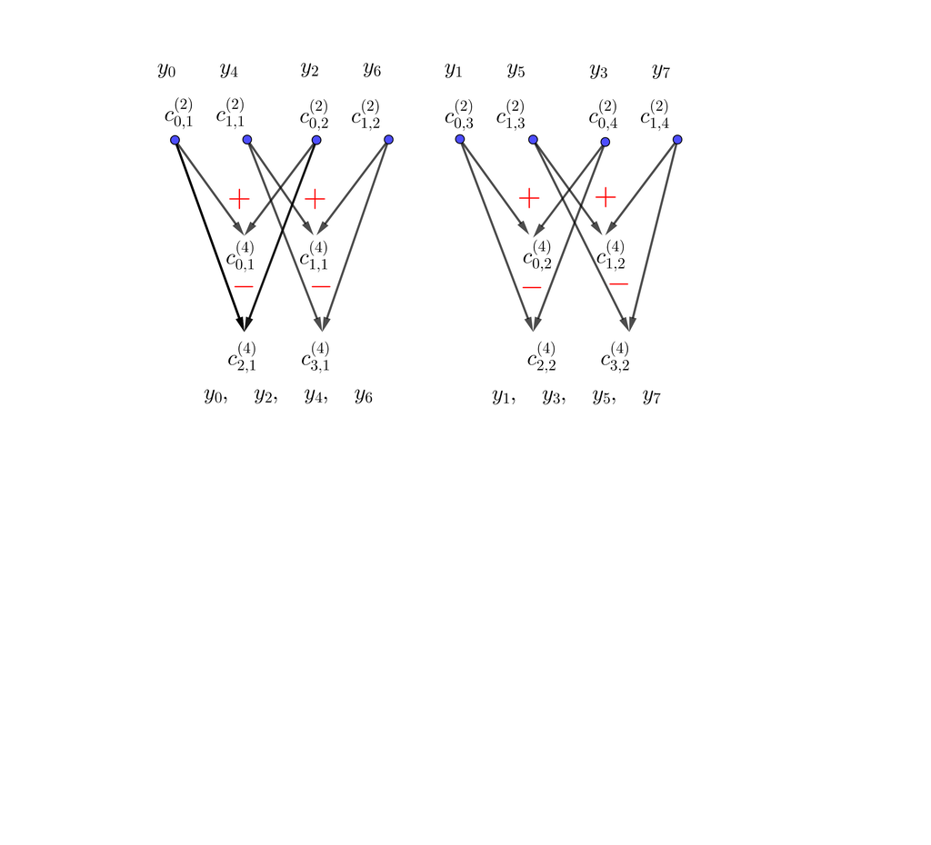

## Algoritmo detallado para \(m=4\)

El gráfico siguiente muestra esquematizado el paso IV:

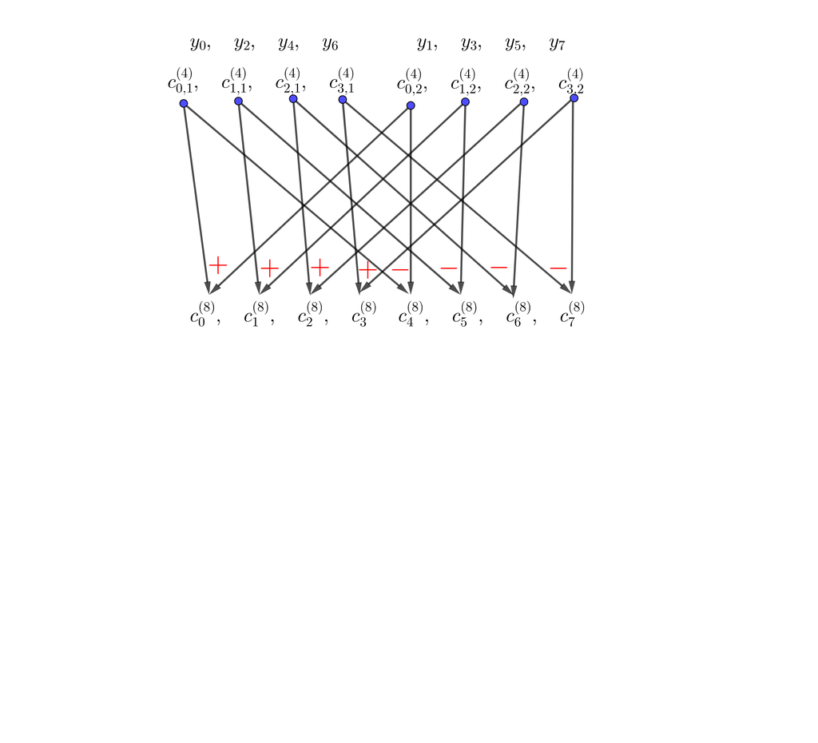

## Transformada rápida de Fourier. Pseudocódigo

### Caso 1: Supondremos que el **lenguaje de programación** en el que se va a programar el código empieza a inicializar en \(1\):

En primer lugar, tenemos que definir la rutina que nos realiza el paso \(\frac{m}{2^{j+1}}\longrightarrow \frac{m}{2^{j}}\).

Le llamamos `SubirNivel` que depende de un vector \(y\), paso \(j\) y del vector `c` donde se guardan los coeficientes \(c_k\):

- `SubirNivel = Rutina(y,j,c)`
  - `Set` \(L=\mathrm{longitud}(\mathbf{c})\) (`Calculamos la longitud del vector donde se guardan los coeficientes` \(c_k\))
  - `Set` \(\mathbf{cn} = \mathbf{c}\) (`En el vector` \(\mathbf{cn}\) `guardaremos los nuevos coeficientes` \(c_k\))

## Transformada rápida de Fourier. Pseudocódigo

- - `For k=1,...,L/2` (`Aplicamos la expresión hallada para los nuevos coeficientes` \(c_k\) `que, recordemos guardaremos en el vector` \(\mathbf{cn}\))
    - `Set` \(cn_k = c_k+\mathrm{e}^{\frac{(k-1)\mathrm{i}\cdot\pi}{2^j}}\cdot c_{k+L/2}\)
    - `Set` \(cn_{L/2+k}=c_k-\mathrm{e}^{\frac{(k-1)\mathrm{i}\cdot\pi}{2^j}}\cdot c_{k+L/2}\)
  - `Set` \(\mathbf{z}=\mathbf{0}\) (`Inicializamos el vector` \(\mathbf{z}\))
  - `Set` \(z[\mathrm{componentes\ pares}]=\mathbf{y}[1:L/2]\) (`Las componentes pares del vector` \(z\) `son las primeras` \(L/2\) `componentes del vector` \(\mathbf{y}\))
  - `Set` \(z[\mathrm{componentes\ impares}]=\mathbf{y}[(L/2+1):L]\) (`Las componentes impares del vector` \(z\) `son las últimas` \(L/2\) `componentes del vector` \(\mathbf{y}\))
  - `Return` \(z\), \(\mathbf{cn}\) (`Devolvemos el vector` \(y\) `arreglado y los nuevos coeficientes guardados en el vector` \(\mathbf{cn}\))

## Transformada rápida de Fourier. Pseudocódigo

- `INPUT m, valores` \(y_k\), \(k=1,\ldots,2 m\).
- `Set` \(p=\ln_2(m)\) (`Calculamos` \(p\) `tal que` \(m=2^p\).)
- `Set` \(z=y\). (`Empezamos a reordenar los valores` \(y_k\), \(k=1,\ldots,2m\) `para poder aplicar el algoritmo. Primeramente hacemos una copia de` \(y\) `en el vector` \(z\) `que será el vector que manipularemos`.)

## Transformada rápida de Fourier. Pseudocódigo

- `For i=1,...p`
  - `For j=1,...,2^(p-1)`
    - `Set` \(aux=z[(1+(j-1)\cdot 2^{p+2-i}):(j\cdot 2^{p+2-i})]\) (`Guardamos las componentes` \(1+(j-1)\cdot 2^{p+2-i},\ldots,j\cdot 2^{p+2-i}\) `del vector` \(z\) `en el vector auxiliar` \(aux\).)
    - `Set` \(aux=aux[\mathrm{componentes\ pares}],aux[\mathrm{componentes\ impares}]\) (`Separamos las componentes pares de las impares en el vector` \(aux\) `escribiendo primero las componentes pares seguidas de las impares`.)
    - `Set` \(z[(1+(j-1)\cdot 2^{p+2-i}):(j\cdot 2^{p+2-i})]=aux[1:2^{p+2-i}]\) (`Guardamos las primeras` \(2^{p+2-i}\) `componentes del vector` \(aux\) `en las correspondientes componentes del vector` \(z\).)
- `Set` \(y=z\) (`Guardamos el nuevo vector` \(z\) `en el vector permutado` \(y\).)

## Transformada rápida de Fourier. Pseudocódigo

- `Set` \(\mathbf{c}^{(2)}=\mathbf{0}\) (`Inicializamos los coeficientes` \(c_k\) `para muestras de longitud` \(2\), \(c_k^{(2)}\), `a` \(0\) `donde el vector` \(\mathbf{0}\) `tiene` \(2m\) `componentes`)
- `For i=0,...,m-1` (`Calculamos los` \(c_k\) `iniciales, es decir, los` \(c_k^{(2)}\) `para las muestras de longitud` \(2\))
  - `Set` \(c_{2i+1}^{(2)}=y_{2i+1}+y_{2i+2}\)
  - `Set` \(c_{2i+2}^{(2)}=y_{2i+1}-y_{2i+2}\)
- `For j=1,...,2^(p-1)` (`Vamos a realizar el primer paso` \(2\longrightarrow 4\))
  - `Set` \(\mathrm{Resultado}_j=SubirNivel(y[(1+(j-1)\cdot 2^2):(j\cdot 2^2)],1,\mathbf{c}^{(2)})\) (`La lista resultado tiene` \(2^{p-1}\) `componentes y el valor de cada una queda indicado en la expresión. Es decir, la componente` \(\mathrm{Resultado}_j\) `tiene dos componentes, una correspondiente al vector` \(y\) `y la otra correspondiente al vector` \(\mathbf{c}\). )

## Transformada rápida de Fourier. Pseudocódigo

- `For i=2,...,p` (`Realizamos todos los demás pasos`)
  - `For j=1,...,2^(p-i)`
    - `Set` \(\mathbf{yj}=[\mathrm{Resultado}_{2j-1}^{y},\mathrm{Resultado}_{2j}^{y}]\) (`Definimos el vector` \(\mathbf{yj}\) `como la unión los vectores` \(y\) `de las listas` \(\mathrm{Resultado}_{2j-1}\) y \(\mathrm{Resultado}_{2j}\))
    - `Set` \(\mathbf{cj}=[Resultado_{2j-1}^{\mathbf{c}},Resultado_{2j}^{\mathbf{c}}]\) (`Idem con los vectores` \(\mathbf{c}\))
    - `Set` \(\mathrm{Resultadon}_j =SubirNivel(\mathbf{yj},i,\mathbf{cj})\)
  - `Set` \(\mathrm{Resultado}=\mathrm{Resultadon}\) (`Actualizamos todo`)
- `Print` \(\mathrm{Resultado}\) ( `es una lista de dos componentes: por un lado tenemos nuestra muestra` \(y\) `original y por otro tenemos calculados los coeficientes` \(c_k\))

## Transformada rápida de Fourier. Pseudocódigo

### Caso 2: Supondremos que el **lenguaje de programación** en el que se va a programar el código empieza a inicializar en \(0\) como Python:

En primer lugar, tenemos que definir la rutina que nos realiza el paso \(\frac{m}{2^{j+1}}\longrightarrow \frac{m}{2^{j}}\).

Le llamamos `SubirNivel` que depende de un vector \(y\), paso \(j\) y del vector `c` donde se guardan los coeficientes \(c_k\):

- `SubirNivel = Rutina(y,j,c)`
  - `Set` \(L=\mathrm{longitud}(\mathbf{c})\) (`Calculamos la longitud del vector donde se guardan los coeficientes` \(c_k\))
  - `Set` \(\mathbf{cn} = \mathbf{c}\) (`En el vector` \(\mathbf{cn}\) `guardaremos los nuevos coeficientes` \(c_k\))

## Transformada rápida de Fourier. Pseudocódigo

- - `For k=0,...,L/2-1` (`Aplicamos la expresión hallada para los nuevos coeficientes` \(c_k\) `que, recordemos guardaremos en el vector` \(\mathbf{cn}\))
    - `Set` \(cn_k = c_k+\mathrm{e}^{\frac{k\mathrm{i}\cdot\pi}{2^j}}\cdot c_{k+L/2}\)
    - `Set` \(cn_{L/2+k}=c_k-\mathrm{e}^{\frac{k\mathrm{i}\cdot\pi}{2^j}}\cdot c_{k+L/2}\)
  - `Set` \(\mathbf{z}=\mathbf{0}\) (`Inicializamos el vector` \(\mathbf{z}\))
  - `Set` \(z[\mathrm{componentes\ pares}]=\mathbf{y}[0:(L/2-1)]\) (`Las componentes pares del vector` \(z\) `son las primeras` \(L/2\) `componentes del vector` \(\mathbf{y}\))
  - `Set` \(z[\mathrm{componentes\ impares}]=\mathbf{y}[(L/2):(L-1)]\) (`Las componentes impares del vector` \(z\) `son las últimas` \(L/2\) `componentes del vector` \(\mathbf{y}\))
  - `Return` \(z\), \(\mathbf{cn}\) (`Devolvemos el vector` \(y\) `arreglado y los nuevos coeficientes guardados en el vector` \(\mathbf{cn}\))

## Transformada rápida de Fourier. Pseudocódigo

- `INPUT m, valores` \(y_k\), \(k=0,\ldots,2 m-1\).
- `Set` \(p=\ln_2(m)\) (`Calculamos` \(p\) `tal que` \(m=2^p\).)
- `Set` \(z=y\). (`Empezamos a reordenar los valores` \(y_k\), \(k=0,\ldots,2m-1\) `para poder aplicar el algoritmo. Primeramente hacemos una copia de` \(y\) `en el vector` \(z\) `que será el vector que manipularemos`.)

## Transformada rápida de Fourier. Pseudocódigo

- `For i=1,...p`
  - `For j=1,...,2^(p-1)`
    - `Set` \(aux=z[((j-1)\cdot 2^{p+2-i}):(j\cdot 2^{p+2-i})]\) (`Guardamos las componentes` \((j-1)\cdot 2^{p+2-i},\ldots,j\cdot 2^{p+2-i}-1\) `del vector` \(z\) `en el vector auxiliar` \(aux\).)
    - `Set` \(aux=aux[\mathrm{componentes\ pares}],aux[\mathrm{componentes\ impares}]\) (`Separamos las componentes pares de las impares en el vector` \(aux\) `escribiendo primero las componentes pares seguidas de las impares`.)
    - `Set` \(z[((j-1)\cdot 2^{p+2-i}):(j\cdot 2^{p+2-i}-1)]=aux[0:(2^{p+2-i}-1)]\) (`Guardamos las primeras` \(2^{p+2-i}\) `componentes del vector` \(aux\) `en las correspondientes componentes del vector` \(z\).)
- `Set` \(y=z\) (`Guardamos el nuevo vector` \(z\) `en el vector permutado` \(y\).)

## Transformada rápida de Fourier. Pseudocódigo

- `Set` \(\mathbf{c}^{(2)}=\mathbf{0}\) (`Inicializamos los coeficientes` \(c_k\) `para muestras de longitud` \(2\), \(c_k^{(2)}\), `a` \(0\) `donde el vector` \(\mathbf{0}\) `tiene` \(2m\) `componentes`)
- `For i=0,...,m-1` (`Calculamos los` \(c_k\) `iniciales, es decir, los` \(c_k^{(2)}\) `para las muestras de longitud` \(2\))
  - `Set` \(c_{2i}^{(2)}=y_{2i}+y_{2i+1}\)
  - `Set` \(c_{2i+1}^{(2)}=y_{2i}-y_{2i+1}\)
- `For j=1,...,2^(p-1)` (`Vamos a realizar el primer paso` \(2\longrightarrow 4\))
  - `Set` \(\mathrm{Resultado}_{j-1}=SubirNivel(y[((j-1)\cdot 2^2):(j\cdot 2^2)],1,\mathbf{c}^{(2)}[((j-1)\cdot 2^2):(j\cdot 2^2)])\) (`La lista resultado tiene` \(2^{p-1}\) `componentes y el valor de cada una queda indicado en la expresión. Es decir, la componente` \(\mathrm{Resultado}_j\) `tiene dos componentes, una correspondiente al vector` \(y\) `y la otra correspondiente al vector` \(\mathbf{c}\). )

## Transformada rápida de Fourier. Pseudocódigo

- `For i=2,...,p` (`Realizamos todos los demás pasos`)
  - `For j=0,...,2^(p-i)-1`
    - `Set` \(\mathbf{yj}=[\mathrm{Resultado}_{2j}^{y},\mathrm{Resultado}_{2j+1}^{y}]\) (`Definimos el vector` \(\mathbf{yj}\) `como la unión los vectores` \(y\) `de las listas` \(\mathrm{Resultado}_{2j-1}\) y \(\mathrm{Resultado}_{2j}\))
    - `Set` \(\mathbf{cj}=[Resultado_{2j}^{\mathbf{c}},Resultado_{2j+1}^{\mathbf{c}}]\) (`Idem con los vectores` \(\mathbf{c}\))
    - `Set` \(\mathrm{Resultadon}_j =SubirNivel(\mathbf{yj},i,\mathbf{cj})\)
  - `Set` \(\mathrm{Resultado}=\mathrm{Resultadon}\) (`Actualizamos todo`)
- `Print` \(\mathrm{Resultado}\) ( `es una lista de dos componentes: por un lado tenemos nuestra muestra` \(y\) `original y por otro tenemos calculados los coeficientes` \(c_k\))

## Ejemplo

Vamos a hallar la **Transformada de Fourier** de la forma: \[ S_m(x)=\frac{a_0+a_m\cos(mx)}{2}+\sum_{j=1}^{m-1} a_j\cos(jx)+\sum_{j=1}^{m-1}b_j\sin(jx), \] con \[ \begin{align*} a_k = & \frac{1}{m}\sum_{i=0}^{2m-1}y_i\cos(kx_i),\ k=0,1,\ldots,m,\\ b_k = & \frac{1}{m}\sum_{i=0}^{2m-1}y_i\sin(kx_i),\ k=0,1,\ldots,m-1.\\ \end{align*} \] que interpola la nube de puntos \((x_k,y_k)\), \(k=0,1,\ldots,2m-1\), con \(m=4\) (\(2m-1=7\)) siguientes: \[ \begin{align*} x_k = & -\pi+\frac{k\pi}{4},\ k=0,1,\ldots,7,\\ x_k = & -3.141593, -2.356194, -1.570796, -0.785398, 0, 0.785398, 1.570796, 2.356194,\\ y_k = & x_k^2=9.8696044, 5.5516525, 2.4674011, 0.6168503, 0, 0.6168503, 2.4674011, 5.5516525, \end{align*} \] usando la Transformada Rápida de Fourier.

## Ejemplo (continuación)

- Paso I: Reordenamos la muestra de \(y_k\) para poder aplicar el algoritmo: \[ \begin{align*} & y_0,\ y_1,\ y_2,\ y_3,\ y_4,\ y_5,\ y_6,\ y_7\\ & y_0,\ y_2,\ y_4,\ y_6,\quad y_1,\ y_3,\ y_5,\ y_7,\\ & \mathrm{Muestra\ 1:\ }y_0,\ y_4,\quad \mathrm{Muestra\ 2:\ }y_2,\ y_6,\quad \mathrm{Muestra\ 3:\ }y_1,\ y_5,\quad \mathrm{Muestra\ 4:\ }y_3,\ y_7,\\ & \mathrm{Muestra\ 1:\ } 9.8696044, 0,\quad \mathrm{Muestra\ 2:\ }2.4674011, 2.4674011,\\ & \mathrm{Muestra\ 3:\ } 5.5516525, 0.6168503,\quad \mathrm{Muestra\ 4:\ }0.6168503, 5.5516525. \end{align*} \]
- Paso II: Calculamos los coeficientes para las muestras 1,2,3 y 4 anteriores: \[ \begin{align*} c_{0,1}^{(2)} = & y_0+y_4 = 9.8696044+0=9.8696044,\quad c_{1,1}^{(2)} = y_0-y_4 = 9.8696044-0=9.8696044,\\ c_{0,2}^{(2)} = & y_2+y_6 = 2.4674011+2.4674011=4.9348022,\quad c_{1,2}^{(2)} = y_2-y_6 = 2.4674011-2.4674011=0,\\ c_{0,3}^{(2)} = & y_1+y_5 = 5.5516525+0.6168503=6.1685028,\quad c_{1,3}^{(2)} = y_1-y_5 = 5.5516525-0.6168503=4.9348022,\\ c_{0,4}^{(2)} = & y_3+y_7 = 0.6168503+5.5516525=6.1685028,\quad c_{1,4}^{(2)} = y_3-y_7 = 0.6168503-5.5516525=-4.9348022. \end{align*} \]

## Ejemplo (continuación)

- Paso IV: Calculamos los coeficientes de la muetra original \(y_0,\ldots,y_7\) en el paso \(4\longrightarrow 8\): \[ \begin{align*} c_0^{(8)} = & y_0+y_1+y_2+y_3+y_4+y_5+y_6+y_7 =9.8696044+5.5516525+2.4674011+0.6168503\\ &\quad +0+0.6168503+2.4674011+5.5516525=27.1414121,\\ c_1^{(8)} = & y_0+\left(\frac{\sqrt{2}}{2}+\frac{\sqrt{2}}{2}\mathrm{i}\right)y_1+\mathrm{i}y_2+\left(\frac{-\sqrt{2}}{2}+\frac{\sqrt{2}}{2}\mathrm{i}\right)y_3-y_4 -\left(\frac{\sqrt{2}}{2}+\frac{\sqrt{2}}{2}\mathrm{i}\right)y_5-\mathrm{i}y_6\\ & \quad +\left(\frac{\sqrt{2}}{2}-\frac{\sqrt{2}}{2}\mathrm{i}\right)y_7\\ = & 9.8696044+\left(\frac{\sqrt{2}}{2}+\frac{\sqrt{2}}{2}\mathrm{i}\right) 5.5516525+ 2.4674011\mathrm{i}+\left(\frac{-\sqrt{2}}{2}+\frac{\sqrt{2}}{2}\mathrm{i}\right) 0.6168503\\ & \quad - 0 -\left(\frac{\sqrt{2}}{2}+\frac{\sqrt{2}}{2}\mathrm{i}\right) 0.6168503-2.4674011\mathrm{i} +\left(\frac{\sqrt{2}}{2}-\frac{\sqrt{2}}{2}\mathrm{i}\right) 5.5516525\\ = & 16.8484686, \end{align*} \]

## Ejemplo (continuación)

- Paso IV (continuación): \[ \begin{align*} c_2^{(8)} = & y_0+\mathrm{i}y_1-y_2-\mathrm{i}y_3+y_4+\mathrm{i}y_5-y_6-\mathrm{i}y_7 =9.8696044+5.5516525\mathrm{i}-2.4674011-0.6168503\mathrm{i}\\ &\quad +0+0.6168503\mathrm{i}-2.4674011-5.5516525\mathrm{i}=4.9348022,\\ c_3^{(8)} = & y_0+\left(-\frac{\sqrt{2}}{2}+\frac{\sqrt{2}}{2}\mathrm{i}\right)y_1-\mathrm{i}y_2+\left(\frac{\sqrt{2}}{2}+\frac{\sqrt{2}}{2}\mathrm{i}\right)y_3-y_4 +\left(\frac{\sqrt{2}}{2}-\frac{\sqrt{2}}{2}\mathrm{i}\right)y_5+\mathrm{i}y_6\\ & \quad -\left(\frac{\sqrt{2}}{2}+\frac{\sqrt{2}}{2}\mathrm{i}\right)y_7\\ = & 9.8696044+\left(-\frac{\sqrt{2}}{2}+\frac{\sqrt{2}}{2}\mathrm{i}\right) 5.5516525- 2.4674011\mathrm{i}+\left(\frac{\sqrt{2}}{2}+\frac{\sqrt{2}}{2}\mathrm{i}\right) 0.6168503\\ & \quad - 0 +\left(\frac{\sqrt{2}}{2}-\frac{\sqrt{2}}{2}\mathrm{i}\right) 0.6168503+2.4674011\mathrm{i} -\left(\frac{\sqrt{2}}{2}+\frac{\sqrt{2}}{2}\mathrm{i}\right) 5.5516525\\ = & 2.8907402, \end{align*} \]

## Ejemplo (continuación)

- Paso IV (continuación): \[ \begin{align*} c_4^{(8)} = & y_0-y_1+y_2-y_3+y_4-y_5+y_6-y_7 =9.8696044-5.5516525+2.4674011-0.6168503\\ &\quad +0-0.6168503+2.4674011-5.5516525=2.4674011,\\ c_5^{(8)} = & y_0-\left(\frac{\sqrt{2}}{2}+\frac{\sqrt{2}}{2}\mathrm{i}\right)y_1+\mathrm{i}y_2+\left(\frac{\sqrt{2}}{2}-\frac{\sqrt{2}}{2}\mathrm{i}\right)y_3-y_4 +\left(\frac{\sqrt{2}}{2}+\frac{\sqrt{2}}{2}\mathrm{i}\right)y_5-\mathrm{i}y_6\\ & \quad +\left(\frac{-\sqrt{2}}{2}+\frac{\sqrt{2}}{2}\mathrm{i}\right)y_7\\ = & 9.8696044-\left(\frac{\sqrt{2}}{2}+\frac{\sqrt{2}}{2}\mathrm{i}\right) 5.5516525+ 2.4674011\mathrm{i}+\left(\frac{\sqrt{2}}{2}-\frac{\sqrt{2}}{2}\mathrm{i}\right) 0.6168503\\ & \quad - 0 +\left(\frac{\sqrt{2}}{2}+\frac{\sqrt{2}}{2}\mathrm{i}\right) 0.6168503-2.4674011\mathrm{i} +\left(-\frac{\sqrt{2}}{2}+\frac{\sqrt{2}}{2}\mathrm{i}\right) 5.5516525\\ = & 2.8907402, \end{align*} \]

## Ejemplo (continuación)

- Paso IV (continuación): \[ \begin{align*} c_6^{(8)} = & y_0-\mathrm{i}y_1-y_2+\mathrm{i}y_3+y_4-\mathrm{i}y_5-y_6+\mathrm{i}y_7 =9.8696044-5.5516525\mathrm{i}-2.4674011+0.6168503\mathrm{i}\\ &\quad +0-0.6168503\mathrm{i}-2.4674011+5.5516525\mathrm{i}=4.9348022,\\ c_7^{(8)} = & y_0+\left(\frac{\sqrt{2}}{2}-\frac{\sqrt{2}}{2}\mathrm{i}\right)y_1-\mathrm{i}y_2-\left(\frac{\sqrt{2}}{2}+\frac{\sqrt{2}}{2}\mathrm{i}\right)y_3-y_4 +\left(-\frac{\sqrt{2}}{2}+\frac{\sqrt{2}}{2}\mathrm{i}\right)y_5+\mathrm{i}y_6\\ & \quad +\left(\frac{\sqrt{2}}{2}+\frac{\sqrt{2}}{2}\mathrm{i}\right)y_7\\ = & 9.8696044+\left(\frac{\sqrt{2}}{2}-\frac{\sqrt{2}}{2}\mathrm{i}\right) 5.5516525- 2.4674011\mathrm{i}-\left(\frac{\sqrt{2}}{2}+\frac{\sqrt{2}}{2}\mathrm{i}\right) 0.6168503\\ & \quad - 0 +\left(-\frac{\sqrt{2}}{2}+\frac{\sqrt{2}}{2}\mathrm{i}\right) 0.6168503+2.4674011\mathrm{i} +\left(\frac{\sqrt{2}}{2}+\frac{\sqrt{2}}{2}\mathrm{i}\right) 5.5516525\\ = & 16.8484686. \end{align*} \]

## Ejemplo (continuación)

Recordemos que para calcular los coeficientes \(a_k\) y \(b_k\), debemos usar la relación siguiente: \[ a_k+\mathrm{i}b_k = \frac{(-1)^k}{m}c_k,\ k=0,1,\ldots,m. \] Como todos los \(c_k\) hallados son reales, es decir, con la parte imaginaria cero, los coeficientes \(b_k\) serán \(0\) y los coeficientes \(a_k\) serán: \[ \begin{align*} a_0 = & \frac{(-1)^0}{m}c_0^{(8)} =\frac{1}{4}\cdot 27.1414121 = 6.785353,\\ a_1 = & \frac{(-1)^1}{m}c_1^{(8)} =\frac{-1}{4}\cdot 16.8484686 = -4.2121172,\\ a_2 = & \frac{(-1)^2}{m}c_2^{(8)} =\frac{1}{4}\cdot 4.9348022 = 1.2337006,\\ a_3 = & \frac{(-1)^3}{m}c_3^{(8)} =\frac{-1}{4}\cdot 2.8907402 = -0.7226851,\\ a_4 = & \frac{(-1)^4}{m}c_4^{(8)} =\frac{1}{4}\cdot 2.4674011 = 0.6168503. \end{align*} \]

## Ejemplo (continuación)

La transformada de Fourier correspondiente a la nube de puntos \((x_k,y_k)\) es la siguiente: \[ \begin{align*} S_{4}(x)= & \frac{6.785353+0.6168503\cdot\cos(4 x)}{2}-4.2121172\cdot\cos(x)+1.2337006\cdot\cos(2x)-0.7226851\cdot\cos(3x),\\ = & 3.3926765-4.2121172\cdot\cos(x)+1.2337006\cdot\cos(2x)-0.7226851\cdot\cos(3x)+0.3084251\cdot\cos(4x). \end{align*} \]

El gráfico siguiente muestra la transformada de Fourier \(S_4(x)\) en negro junto con la nube de puntos en rojo.

## Ejemplo (continuación)

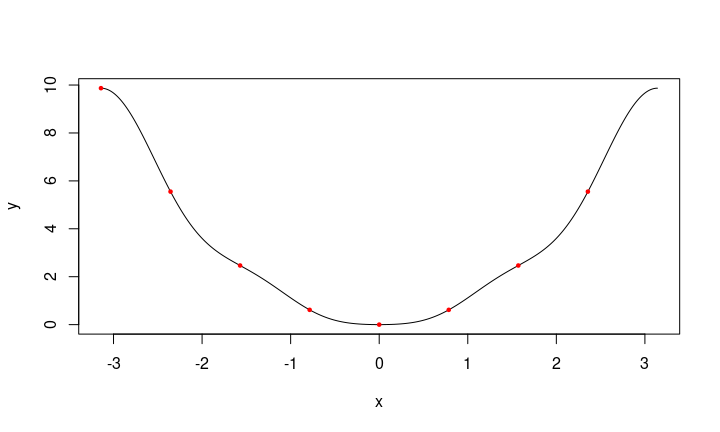

## Trans. rápida de Fourier en cualquier intervalo

Supongamos que nuestra nube de puntos \((t_k,y_k)\), \(k=0,1,\ldots,2m-1\) está en un intervalo \([a,b]\) y queremos hallar la correspondiente **transformada de Fourier** de dicha nube para este intervalo.

En este caso, hemos de tener en cuenta la aplicación siguiente que nos transforma valores del intervalo \([-\pi,\pi]\) al intervalo \([a,b]\) y viceversa: \[ \begin{align*} [-\pi,\pi] & \longrightarrow [a,b]\\ x & \longrightarrow t=\frac{(b-a)}{2\pi}x+\frac{a+b}{2},\\ x=\frac{2\pi}{(b-a)}\left(t-\frac{(a+b)}{2}\right) &\longleftarrow t. \end{align*} \]

## Trans. rápida de Fourier en cualquier intervalo

Entonces la **función transformada de Fourier** en el intervalo \([a,b]\) será de la forma: \[ \begin{align*} S_m(t)= & \frac{a_0+a_m\cos\left(\frac{2\pi m}{(b-a)}\left(t-\frac{(a+b)}{2}\right)\right)}{2}\\ & \quad +\sum_{j=1}^{m-1} a_j\cos\left(\frac{2\pi j}{(b-a)}\left(t-\frac{(a+b)}{2}\right)\right)\\ & \quad +\sum_{j=1}^{m-1}b_j\sin\left(\frac{2\pi j}{(b-a)}\left(t-\frac{(a+b)}{2}\right)\right), \end{align*} \]

## Trans. rápida de Fourier en cualquier intervalo

donde: \[ \begin{align*} a_k = & \frac{1}{m}\sum_{i=0}^{2m-1}y_i\cos\left(\frac{2\pi k}{(b-a)}\left(t_i-\frac{(a+b)}{2}\right)\right),\ k=0,1,\ldots,m,\\ b_k = & \frac{1}{m}\sum_{i=0}^{2m-1}y_i\sin\left(\frac{2\pi k}{(b-a)}\left(t_i-\frac{(a+b)}{2}\right)\right),\ k=0,1,\ldots,m-1.\\ \end{align*} \]

En la práctica se transforma la nube de puntos \((t_k,y_k)\), \(k=0,1,\ldots,2m-1\) en el intervalo \([-\pi,\pi]\), \[ (t_k,y_k)\longrightarrow \left(x_k=\frac{2\pi}{(b-a)}\left(t_k -\frac{(a+b)}{2}\right),y_k\right),\ k=0,1,\ldots,2m-1, \] se calcula la **función transformada de Fourier** en el intervalo \([-\pi,\pi]\) hallando los coeficientes \(a_k\) y \(b_k\) y por último se considera la expresión anterior \(S_m(t)\).

## Ejemplo

Vamos a hallar la transformada de Fourier de los puntos \((x_k,y_k)\), \(k=0,1\ldots,7\) (\(m=4\)) en el intervalo \([0,1]\), con \(y_k=x_k^2\).

## Ejemplo (continuación)

Si aplicamos la Transformada rápida de Fourier a la nube de puntos anteriores obtenemos los coeficientes \(c_k\) siguientes: \[ \begin{align*} c_0 = & 2.1875+0i,\quad c_1 = -0.07322330470336-1.20710678118655i,\\ c_2 = & -0.375-0.5i,\quad c_3 = -0.426776695296637-0.207106781186548i,\\ c_4 = & -0.4375+0i,\quad c_5 = -0.426776695296637+0.207106781186549i,\\ c_6 = & -0.375000000000001+0.5i,\quad c_7 = -0.07322330470336+1.20710678118655i. \end{align*} \] Los coeficientes \(a_k\) y \(b_k\) usando la expresión \[ a_k+\mathrm{i}b_k = \frac{(-1)^k}{m}c_k,\ k=0,1,\ldots,m. \]

## Ejemplo (continuación)

serán: \[ \begin{align*} a_0 = & \mathrm{Re}\left(\frac{(-1)^0\cdot c_0}{m}\right)=\mathrm{Re}\left(\frac{1\cdot (2.1875+0i)}{4}\right)=0.546875,\\ a_1 = & \mathrm{Re}\left(\frac{(-1)^1\cdot c_1}{m}\right)=\mathrm{Re}\left(\frac{-1\cdot (-0.07322330470336-1.20710678118655i)}{4}\right)=0.0183058,\\ a_2 = & \mathrm{Re}\left(\frac{(-1)^2\cdot c_2}{m}\right)=\mathrm{Re}\left(\frac{1\cdot (-0.375-0.5i)}{4}\right)=-0.09375,\\ a_3 = & \mathrm{Re}\left(\frac{(-1)^3\cdot c_3}{m}\right)=\mathrm{Re}\left(\frac{-1\cdot (-0.426776695296637-0.207106781186548i)}{4}\right)=0.1066942,\\ a_4 = & \mathrm{Re}\left(\frac{(-1)^4\cdot c_4}{m}\right)=\mathrm{Re}\left(\frac{1\cdot (-0.4375+0i)}{4}\right)=-0.109375, \end{align*} \]

\[ \begin{align*} b_0 = & 0,\\ b_1 = & \mathrm{Im}\left(\frac{(-1)^1\cdot c_1}{m}\right)=\mathrm{Im}\left(\frac{-1\cdot (-0.07322330470336-1.20710678118655i)}{4}\right)=0.3017767,\\ b_2 = & \mathrm{Im}\left(\frac{(-1)^2\cdot c_2}{m}\right)=\mathrm{Im}\left(\frac{1\cdot (-0.375-0.5i)}{4}\right)=-0.125,\\ b_3 = & \mathrm{Im}\left(\frac{(-1)^3\cdot c_3}{m}\right)=\mathrm{Im}\left(\frac{-1\cdot (-0.426776695296637-0.207106781186548i)}{4}\right)=0.0517767,\\ b_4 = & 0. \end{align*} \]

## Ejemplo (continuación)

La transformada de Fourier en el intervalo \([-\pi,\pi]\) será: \[ \begin{align*} S_{4}(x)= & \frac{0.546875-0.109375\cdot\cos(4 x)}{2}+0.0183058\cdot\cos(x)-0.09375\cdot\cos(2x)+0.1066942\cdot\cos(3x)\\ & \quad +0.3017767\cdot\sin(x)-0.125\cdot\sin(2x)+0.0517767\cdot\sin(3x) \\= & 0.2734375+0.0183058\cdot\cos(x)-0.09375\cdot\cos(2x)+0.1066942\cdot\cos(3x)-0.0546875\cdot\cos(4x)\\ & \quad +0.3017767\cdot\sin(x)-0.125\cdot\sin(2x)+0.0517767\cdot\sin(3x). \end{align*} \]

Usando el cambio \(x=2\pi \left(t-\frac{1}{2}\right)\), la transformada de Fourier en el intervalo \([0,1]\) será: \[ \begin{align*} S_{4}(t)= & 0.2734375+0.0183058\cdot\cos\left(2\pi \left(t-\frac{1}{2}\right)\right)-0.09375\cdot\cos\left(4\pi \left(t-\frac{1}{2}\right)\right)\\ & \quad +0.1066942\cdot\cos\left(6\pi \left(t-\frac{1}{2}\right)\right)-0.0546875\cdot\cos\left(8\pi \left(t-\frac{1}{2}\right)\right)\\ & \quad +0.3017767\cdot\sin\left(2\pi \left(t-\frac{1}{2}\right)\right)-0.125\cdot\sin\left(4\pi \left(t-\frac{1}{2}\right)\right)+0.0517767\cdot\sin\left(6\pi \left(t-\frac{1}{2}\right)\right). \end{align*} \]

El gráfico siguiente muestra la transformada de Fourier \(S_4(x)\) en negro junto con la nube de puntos en rojo.

## Ejemplo (continuación)

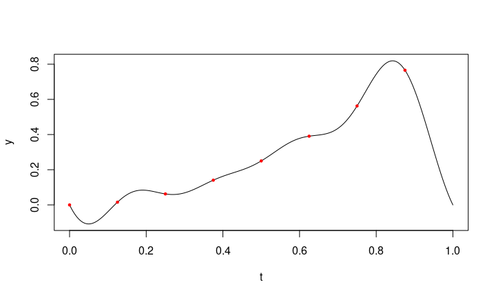